# Census_income

Arsen Samaiev

19 03 2021

# **Introduction**

In this analysis i will use the **Adult Income** data set. It’s a decent data set, which is suitable for a project due to it’s amount of data and attributes. The main idea is to determine whether the person has the income higher or lower than 50k.

This data set isn’t preprocessed and has some missing values. Further, I will explain every single attribute and make this data set clearer for analysis, so that I could fit it in the prediction models.

[figure not shown]

# **Data Understanding**

The data, that I’m going to use are available freely on the official [UCI Machine Learning](https://archive.ics.uci.edu/ml/datasets/Census+Income) page. There are 15 attributes in total(categorical and integer only).

## **Overall information**

- Data Set Characteristics – Multivariate
- Attribute Characteristics – Categorical, Integer
- Associated Tasks – Classification
- Number of Instances – 32561
- Number of Attributes – 15
- Missing Values – Yes
- Area – Social
- Date Donated – 01.05.1996
- Number of Web Hits – 395836

## **Attribute Information:**

1. Age (Integer, Continuous)
2. Workclass (Categorical)
- Private, Self-emp-not-inc, Self-emp-inc, Federal-gov, Local-gov, State-gov, Without-pay, Never-worked
3. Fnlwgt (Integer, Continuous)
- Represents final weight, which is the number of units in the target population that the responding unit represents
4. Education (Categorical)
- Bachelors, Some-college, 11th, HS-grad, Prof-school, Assoc-acdm, Assoc-voc, 9th, 7th-8th, 12th, Masters, 1st-4th, 10th, Doctorate, 5th-6th, Preschool
5. Education–num (Integer, Continuous)
- Represents each “Education” variable category with a specific number
6. Marital-status (Categorical)
- Married-civ-spouse, Divorced, Never-married, Separated, Widowed, Married-spouse-absent, Married-AF-spouse
7. Occupation (Categorical)
- Tech-support, Craft-repair, Other-service, Sales, Exec-managerial, Prof-specialty, Handlers-cleaners, Machine-op-inspct, Adm-clerical, Farming-fishing, Transport-moving, Priv-house-serv, Protective-serv, Armed-Forces
8. Relationship (Categorical)
- Wife, Own-child, Husband, Not-in-family, Other-relative, Unmarried
9. Race (Categorical)
- White, Asian-Pac-Islander, Amer-Indian-Eskimo, Other, Black
10. Sex (Categorical)
- Male, Female
11. Capital-gain (Integer, Continuous)
12. Capital-loss (Integer, Continuous)
13. Hours-per-week (Integer, Continuous)
14. Native-country (Categorical)
- United-States, Cambodia, England, Puerto-Rico, Canada, Germany, Outlying-US(Guam-USVI-etc), India, Japan, Greece, South, China, Cuba, Iran, Honduras, Philippines, Italy, Poland, Jamaica, Vietnam, Mexico, Portugal, Ireland, France, Dominican-Republic, Laos, Ecuador, Taiwan, Haiti, Columbia, Hungary, Guatemala, Nicaragua, Scotland, Thailand, Yugoslavia, El-Salvador, Trinadad&Tobago, Peru, Hong, Holand-Netherlands
15. Income (Categorical)
- “>50k”, “<=50k”

## **Loading the Data**

I’m going to load the data set straight out from the index page. And the names will be changed by using this same page.

```r
  dataseturl = 'http://archive.ics.uci.edu/ml/machine-learning-databases/adult/adult.data'
  datanameurl = 'http://archive.ics.uci.edu/ml/machine-learning-databases/adult/adult.names'
  census = read.table(dataseturl,sep = ',', fill = F, strip.white = T)
  censusnames = readLines(datanameurl)[97:110]
  censusnames = as.character(lapply(strsplit(censusnames,':'), function(x) x[1]))
  censusnames = c(censusnames,'income')
  colnames(census) = censusnames
```

To make this data set more suitable for modeling and easier for coding, I will change the dash separated attributes to become separated by dots.

```r
names(census) = make.names(names(census))
```

The summarized data look like this

```
##       age         workclass             fnlwgt         education
##  Min.   :17.00   Length:32561       Min.   :  12285   Length:32561
##  1st Qu.:28.00   Class :character   1st Qu.: 117827   Class :character
##  Median :37.00   Mode  :character   Median : 178356   Mode  :character
##  Mean   :38.58                      Mean   : 189778
##  3rd Qu.:48.00                      3rd Qu.: 237051
##  Max.   :90.00                      Max.   :1484705
##  education.num   marital.status      occupation        relationship
##  Min.   : 1.00   Length:32561       Length:32561       Length:32561
##  1st Qu.: 9.00   Class :character   Class :character   Class :character
##  Median :10.00   Mode  :character   Mode  :character   Mode  :character
##  Mean   :10.08
##  3rd Qu.:12.00
##  Max.   :16.00
##      race               sex             capital.gain    capital.loss
##  Length:32561       Length:32561       Min.   :    0   Min.   :   0.0
##  Class :character   Class :character   1st Qu.:    0   1st Qu.:   0.0
##  Mode  :character   Mode  :character   Median :    0   Median :   0.0
##                                        Mean   : 1078   Mean   :  87.3
##                                        3rd Qu.:    0   3rd Qu.:   0.0
##                                        Max.   :99999   Max.   :4356.0
##  hours.per.week  native.country        income
##  Min.   : 1.00   Length:32561       Length:32561
##  1st Qu.:40.00   Class :character   Class :character
##  Median :40.00   Mode  :character   Mode  :character
##  Mean   :40.44
##  3rd Qu.:45.00
##  Max.   :99.00
```

The structure of loaded data

```r
str(census)
```

```
## 'data.frame':    32561 obs. of  15 variables:
##  $ age           : int  39 50 38 53 28 37 49 52 31 42 ...
##  $ workclass     : chr  "State-gov" "Self-emp-not-inc" "Private" "Private" ...
##  $ fnlwgt        : int  77516 83311 215646 234721 338409 284582 160187 209642 45781 159449 ...
##  $ education     : chr  "Bachelors" "Bachelors" "HS-grad" "11th" ...
##  $ education.num : int  13 13 9 7 13 14 5 9 14 13 ...
##  $ marital.status: chr  "Never-married" "Married-civ-spouse" "Divorced" "Married-civ-spouse" ...
##  $ occupation    : chr  "Adm-clerical" "Exec-managerial" "Handlers-cleaners" "Handlers-cleaners" ...
##  $ relationship  : chr  "Not-in-family" "Husband" "Not-in-family" "Husband" ...
##  $ race          : chr  "White" "White" "White" "Black" ...
##  $ sex           : chr  "Male" "Male" "Male" "Male" ...
##  $ capital.gain  : int  2174 0 0 0 0 0 0 0 14084 5178 ...
##  $ capital.loss  : int  0 0 0 0 0 0 0 0 0 0 ...
##  $ hours.per.week: int  40 13 40 40 40 40 16 45 50 40 ...
##  $ native.country: chr  "United-States" "United-States" "United-States" "United-States" ...
##  $ income        : chr  "<=50K" "<=50K" "<=50K" "<=50K" ...
```

## **Missing Values**

The " ?" value only appears in categorical data, which doesn’t “harm” any other numerical values. To avoid dropping the rows with " ?" values, they will be changed to “Unknown” in future preparation process.

## **Attribute Visualization**

- Histograms of the numeric attributes

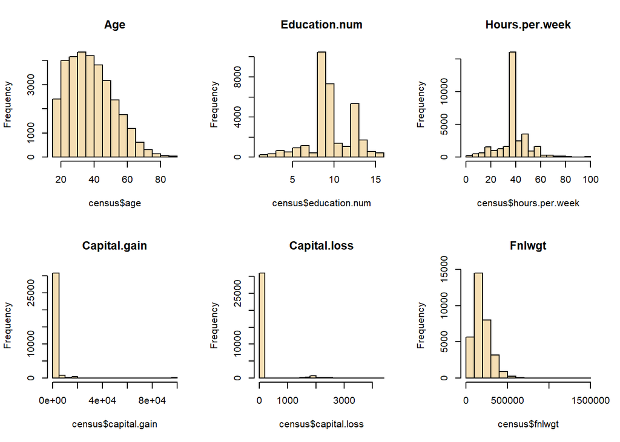

```r
par(mfrow=c(2,3))
hist(census$age, main = "Age", col = "Wheat")
hist(census$education.num, main = "Education.num", col = "Wheat")
hist(census$hours.per.week, main = "Hours.per.week", col = "Wheat")
hist(census$capital.gain, main = "Capital.gain", col = "Wheat")
hist(census$capital.loss, main = "Capital.loss", col = "Wheat")
hist(census$fnlwgt, main = "Fnlwgt", col = "Wheat")
```

The histograms above show the average *age*, *education.num* and *hours.per.week*. These values provide the needed information for analysis by helping to understand which optimal age and education is required to gain over 50k. The other 3 variables (capital gain/loss and fnlwgt) don’t provide useful information for analysis. Just because a lot of values are same or have no visible differentiation needed for analysis. That’s why they will be removed in the preparation part.

- Barplots of the categorical attributes

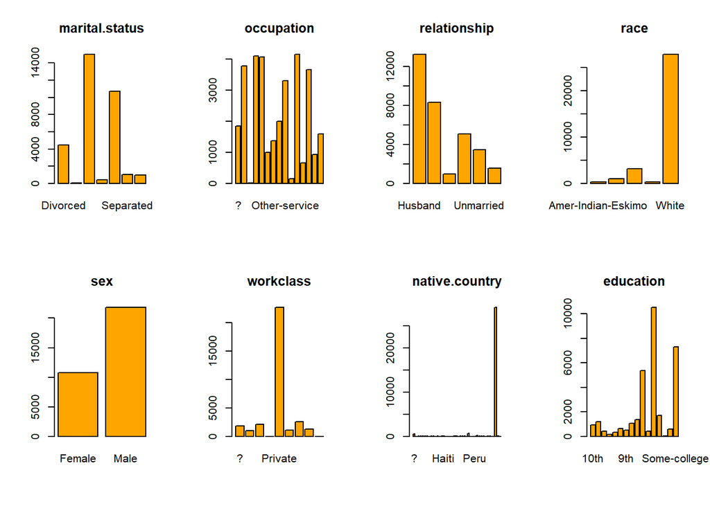

```r
par(mfrow=c(2,4))
barplot(table(census$marital.status),main='marital.status',col = 'orange')
barplot(table(census$occupation),main='occupation',col = 'orange')
barplot(table(census$relationship),main='relationship',col = 'orange')
barplot(table(census$race),main='race',col = 'orange')
barplot(table(census$sex),main='sex',col = 'orange')
barplot(table(census$workclass),main='workclass',col = 'orange')
barplot(table(census$native.country),main='native.country',col = 'orange')
barplot(table(census$education),main = 'education',col = 'orange')
```

The barplots above show the statistics of different status each unit has. Mostly married, white males with above average education are leading. The *native.country* variable will be removed in the preparation stage, because almost 90% of people are from the United States. *Education* will also be removed due to redundancy. The main reason why is because *education.num* explains the same categories in numeric values and it’s easier to work with this kind of data. *Relationship* will be removed as well. This attribute complicates the data set, because it can be explained by *sex* and *marital.status*.

- Histogram of age by income group

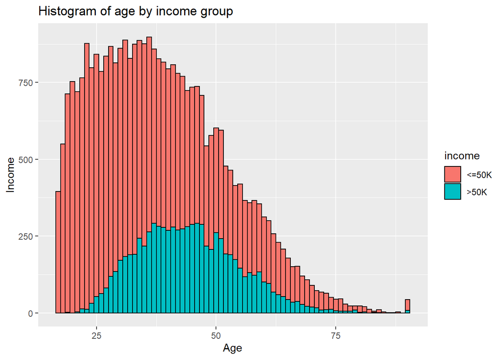

```r
ggplot(census) + aes(x=as.numeric(age), group=income, fill=income) +  ggtitle("Histogram of age by income group") + xlab("Age") + ylab("Income") +
    geom_histogram(binwidth=1, color='black')
```

By viewing the plot it’s logical to admit that in general people aged from 25 to 50 are more likely to earn more than 50k.

## **Attribute Correlation**

- Correlation between numerical variables and income

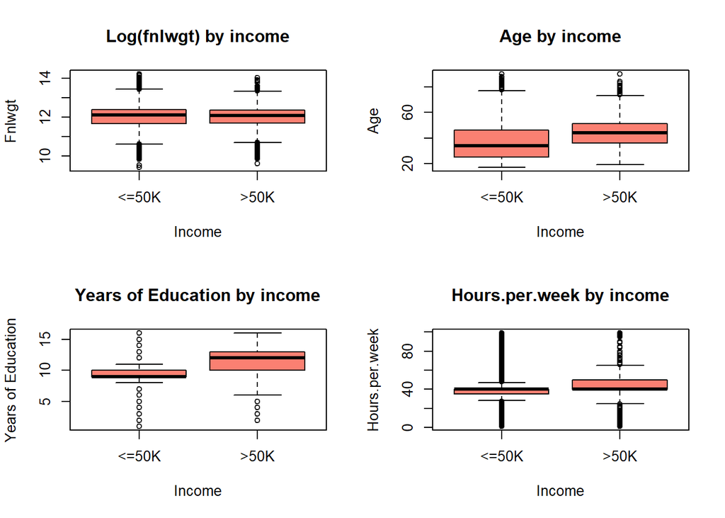

```r
par(mfrow=c(2,2))
boxplot (log(fnlwgt)~income, data =census, main = "Log(fnlwgt) by income", xlab = "Income", ylab = "Fnlwgt", col = "salmon")
boxplot (age~income, data =census, main = "Age by income", xlab = "Income", ylab = "Age", col = "salmon")
boxplot (education.num~income, data =census, main = "Years of Education by income",
xlab = "Income", ylab = "Years of Education", col = "salmon")
boxplot (hours.per.week~income, data =census, main = "Hours.per.week by income",
xlab = "Income", ylab = "Hours.per.week", col = "salmon")
```

- These correlation boxplots prove that *fnlwgt* doesn’t bring much of use. Those who are older, than 30 and have at least 8+ years of education are most likely to earn “>50k”.
- Correlation measures the relation between two variables. When two variables are highly correlated that they can explain each other, then the collinearity problem has to be dealt with.

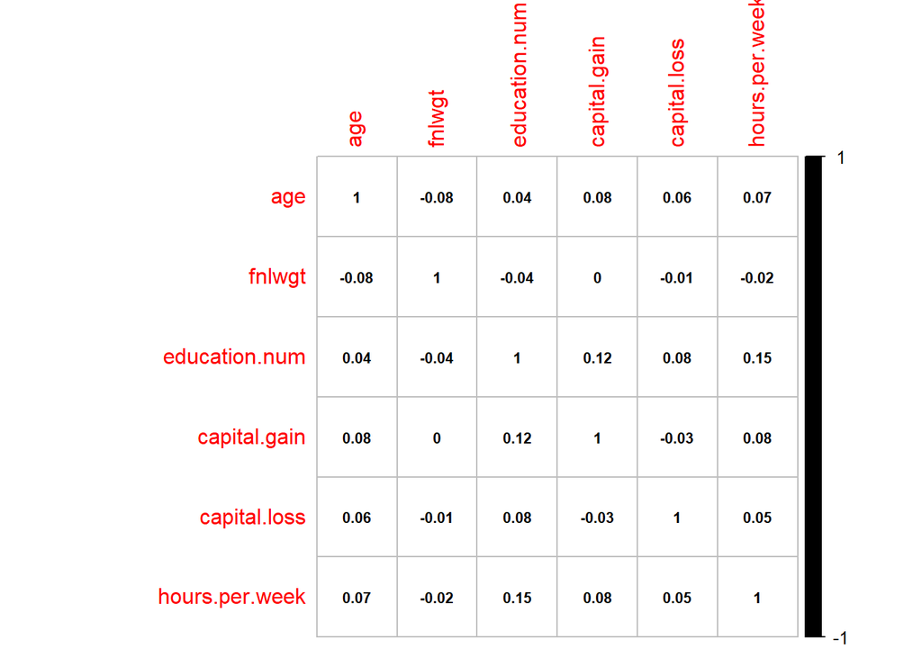

```r
correlat = cor(census[c(1,3,5,11,12,13)])
corrplot(correlat, col = "black", number.cex = .7, method = "number")
```

- Corrplot shows no correlation between the variables. No collinearity problem detected.
- Correlation between categorical variables and income

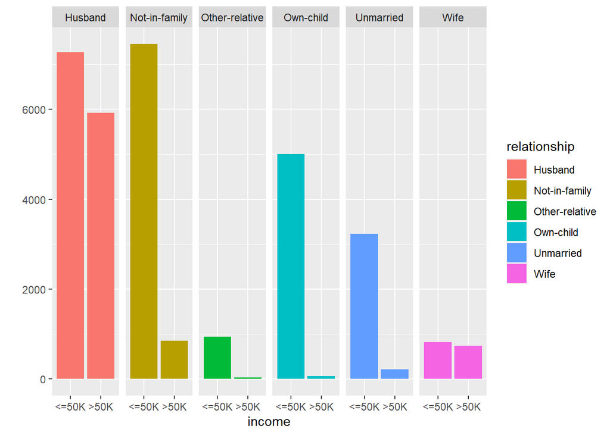

```r
qplot(income, data = census, fill = relationship) + facet_grid (. ~ relationship)
```

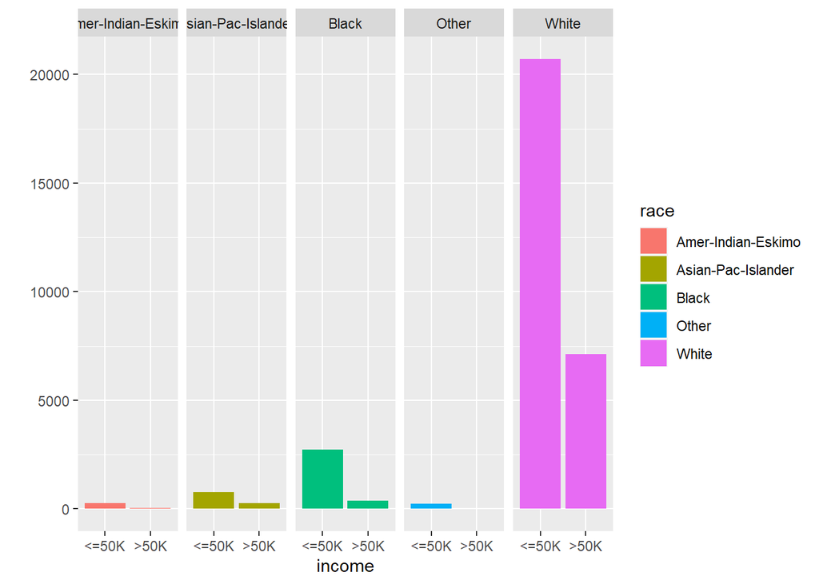

```r
qplot(income, data = census, fill = race) + facet_grid (. ~ race)
```

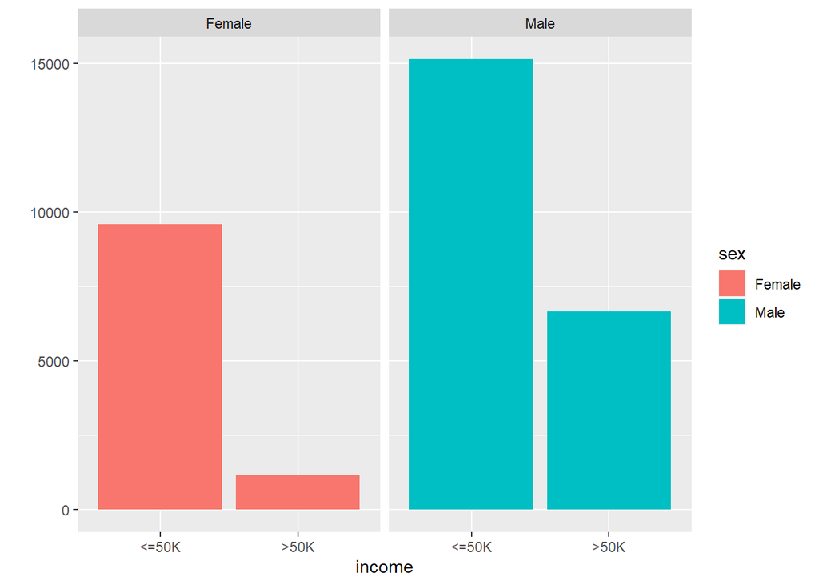

```r
qplot(income, data = census, fill = sex) + facet_grid (. ~ sex)
```

By viewing these correlations it’s visible that those, who are married have the biggest probability of earning “>50k”. Mostly white, male and in a higher job hierarchy. Due to *workclass*, *occupation*, *native.country* and *marital-status* having long names and vast group differentiation, they cannot be visualized properly. Their correlations will be shown in the data preparation phase.

# **Data Preparation**

- Firstly, I’m going to remove the useless variables from this data frame.

```r
census$education = NULL
census$fnlwgt = NULL
```

- Secondly, I will regroup the categorical data for better understanding and analysis

## **Workclass**

- It is obvious that the majority makes less than 50k. However, those, who make over 50k are mainly in midcareer. That’s why the *workclass* variable has to be regrouped. But first, the missing values have to be dealt with. The variable can be spread into 4 different groups:
1. Government (Federal-gov, Local-gov, State-gov)
2. Self-employed (Self-emp-inc, Self-emp-not-inc)
3. Private
4. Other (Unknown, Never-worked, Without-pay)

```r
census$workclass = gsub('^Federal-gov', 'Government', census$workclass)
census$workclass = gsub('^Local-gov', 'Government', census$workclass)
census$workclass = gsub('^State-gov', 'Government', census$workclass)

census$workclass = gsub('^Self-emp-inc', 'Self-Employed', census$workclass)
census$workclass = gsub('^Self-emp-not-inc', 'Self-Employed', census$workclass)

census$workclass = gsub('^Never-worked', 'Other', census$workclass)
census$workclass = gsub('^Without-pay', 'Other', census$workclass)
census$workclass = gsub('^Other', 'Other', census$workclass)
census$workclass = gsub('^Unknown', 'Other', census$workclass)

census$workclass = as.factor(census$workclass)
levels(census$workclass)[1] = 'Unknown'
census$workclass = gsub('Unknown', 'Other', census$workclass)
census$workclass = as.factor(census$workclass)
summary(census$workclass)
```

```
##    Government         Other       Private Self-Employed
##          4351          1857         22696          3657
```

After splitting, I’ll create a new data frame, which has the *workclass* by *income* variable relations and their count. Each group will be divided to the one, that earns “<=50k” and “>50k”.

```r
job = data.frame(table(census$income,census$workclass))
names(job) = c('income', 'workclass', 'count')
job
```

```
##   income     workclass count
## 1  <=50K    Government  3010
## 2   >50K    Government  1341
## 3  <=50K         Other  1666
## 4   >50K         Other   191
## 5  <=50K       Private 17733
## 6   >50K       Private  4963
## 7  <=50K Self-Employed  2311
## 8   >50K Self-Employed  1346
```

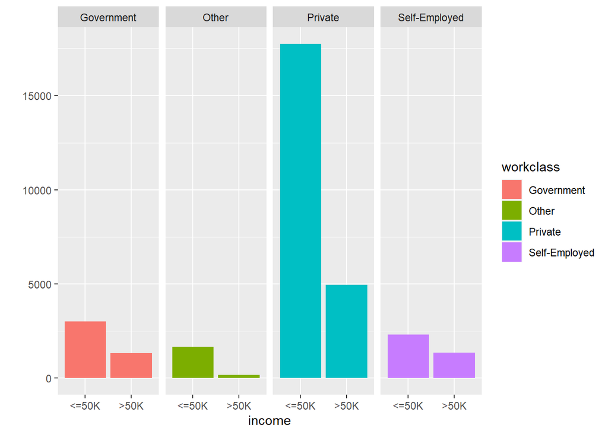

```r
qplot(income, data = census, fill = workclass) + facet_grid (. ~ workclass)
```

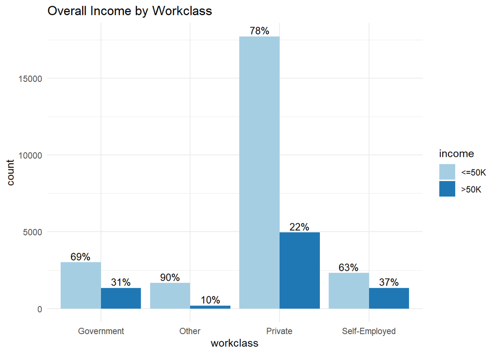

```r
ggplot(data = job, aes(x = workclass, y = count, fill = income)) +
  geom_bar(stat = "identity", position = position_dodge()) +
  geom_text(aes(label = label), vjust = -0.3, color="black",
            position = position_dodge(0.9), size = 3.5) +
  scale_fill_brewer(palette = "Paired") +
  theme_minimal() +
  ggtitle("Overall Income by Workclass")
```

The plot shows how the income differs by groups, where “self-employed” group is leading by income ratio.

## **Education-num**

- Since *education-num* is a continuous representation of *education* variable. The same barplot will be used to visualize relations between *education-num* and *income*.

```r
  study = data.frame(table(census$income, census$education.num))
  names(study) = c('income', 'education.num', 'count')
  study
```

```
##    income education.num count
## 1   <=50K             1    51
## 2    >50K             1     0
## 3   <=50K             2   162
## 4    >50K             2     6
## 5   <=50K             3   317
## 6    >50K             3    16
## 7   <=50K             4   606
## 8    >50K             4    40
## 9   <=50K             5   487
## 10   >50K             5    27
## 11  <=50K             6   871
## 12   >50K             6    62
## 13  <=50K             7  1115
## 14   >50K             7    60
```

[output cut: 18 more lines]

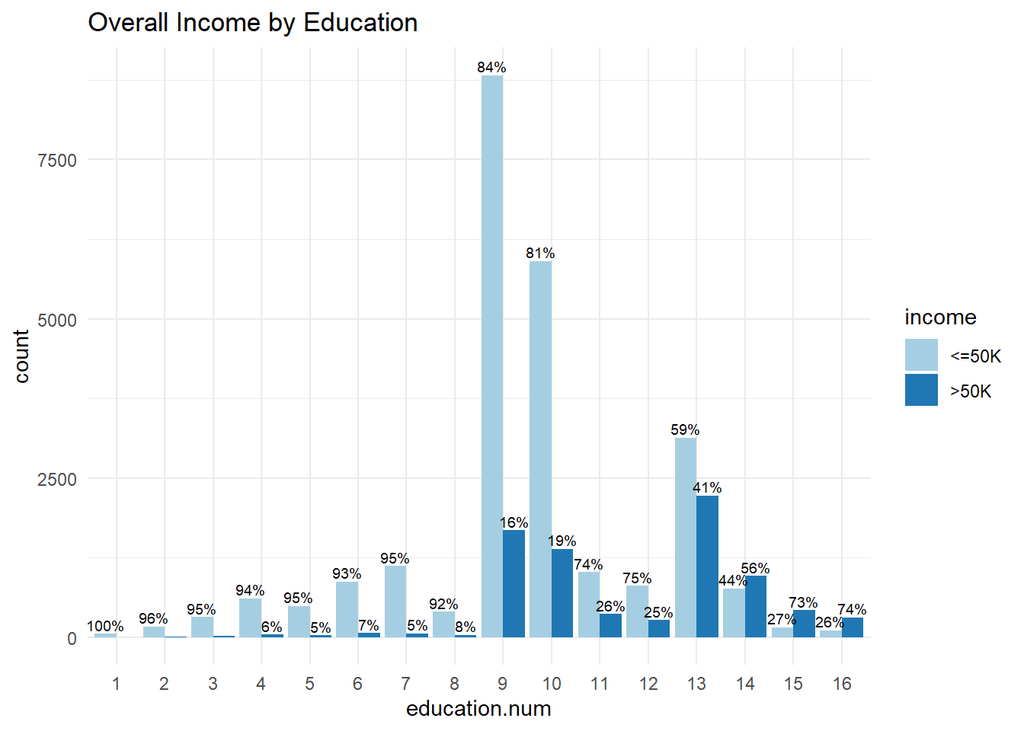

```r
  ggplot(data = study, aes(x = education.num, y = count, fill = income)) +
    geom_bar(stat = "identity", position = position_dodge()) +
    geom_text(aes(label = label), vjust = -0.3, color="black",
              position = position_dodge(0.9), size = 2.5) +
    scale_fill_brewer(palette = "Paired") +
    theme_minimal() +
    ggtitle("Overall Income by Education")
```

- The graph shows, that the higher the education is the bigger is the income. The numbers grow after the 8th group.

## **Occupation**

This variable can also be regrouped for better visualization and understanding. There are 6 visible groups:

1. Blue-collar (Craft-repair, Farming-fishing, Handlers-cleaners, Machine-op-inspct, Transport-moving)
2. White-collar (Adm-clerical, Exec-managerical)
3. Sales
4. Service (Other-service, Priv-house-serv, Protective-serv, Tech-support)
5. Professional (Prof-speciality)
6. Other (Unknown, Armed-forces)

```r
census$occupation = gsub('Adm-clerical', 'White-Collar', census$occupation)
census$occupation = gsub('Craft-repair', 'Blue-Collar', census$occupation)
census$occupation = gsub('Exec-managerial', 'White-Collar', census$occupation)
census$occupation = gsub('Farming-fishing', 'Blue-Collar', census$occupation)
census$occupation = gsub('Handlers-cleaners', 'Blue-Collar', census$occupation)
census$occupation = gsub('Machine-op-inspct', 'Blue-Collar', census$occupation)
census$occupation = gsub('Other-service', 'Service', census$occupation)
census$occupation = gsub('Priv-house-serv', 'Service', census$occupation)
census$occupation = gsub('Prof-specialty', 'Professional', census$occupation)
census$occupation = gsub('Protective-serv', 'Service', census$occupation)
census$occupation = gsub('Tech-support', 'Service', census$occupation)
census$occupation = gsub('Transport-moving', 'Blue-Collar', census$occupation)
census$occupation = gsub('Unknown', 'Other', census$occupation)
census$occupation = gsub('Armed-Forces', 'Other', census$occupation)
census$occupation = as.factor(census$occupation)
levels(census$occupation)[1] = 'Unknown'
census$occupation = gsub('Unknown', 'Other', census$occupation)
census$occupation = as.factor(census$occupation)
summary(census$occupation)
```

```
##  Blue-Collar        Other Professional        Sales      Service White-Collar
##        10062         1852         4140         3650         5021         7836
```

```r
occ= data.frame(table(census$income, census$occupation))
names(occ) = c('income', 'occupation', 'count')
occ
```

```
##    income   occupation count
## 1   <=50K  Blue-Collar  8362
## 2    >50K  Blue-Collar  1700
## 3   <=50K        Other  1660
## 4    >50K        Other   192
## 5   <=50K Professional  2281
## 6    >50K Professional  1859
## 7   <=50K        Sales  2667
## 8    >50K        Sales   983
## 9   <=50K      Service  4389
## 10   >50K      Service   632
## 11  <=50K White-Collar  5361
## 12   >50K White-Collar  2475
```

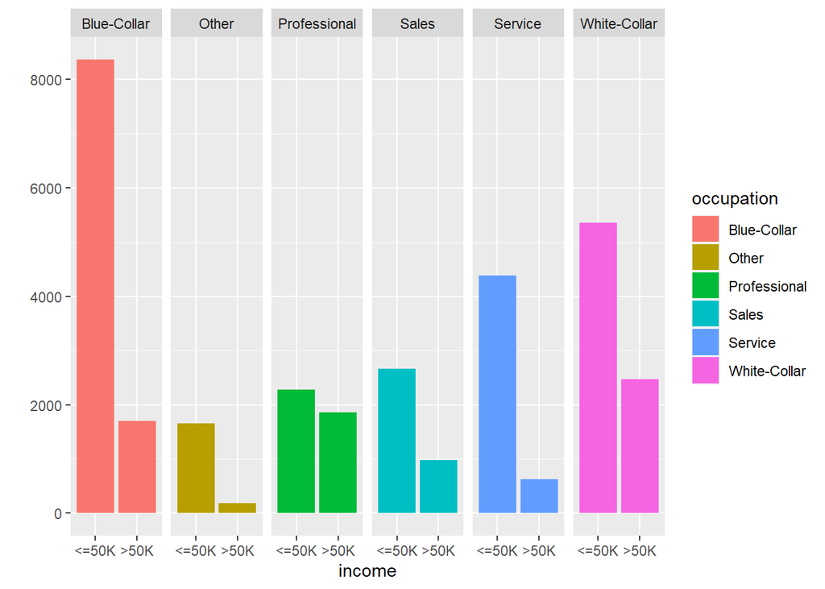

```r
qplot(income, data = census, fill = occupation) + facet_grid (. ~ occupation)
```

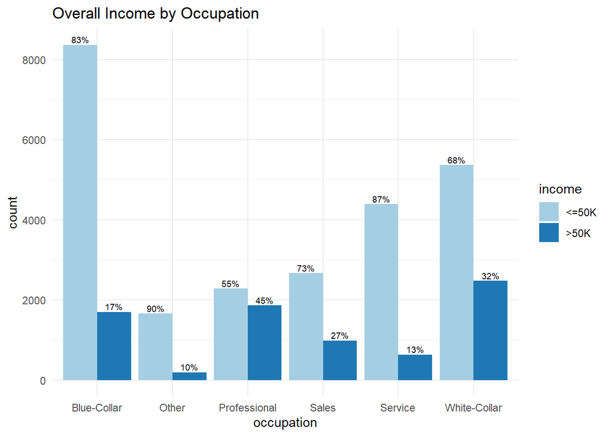

```r
ggplot(data = occ, aes(x = occupation,y = count, fill = income)) +
  geom_bar(stat = "identity", position = position_dodge()) +
  geom_text(aes(label = label), vjust = -0.3, color="black",
            position = position_dodge(0.9), size = 2.5) +
  scale_fill_brewer(palette = "Paired") +
  theme_minimal() +
  ggtitle("Overall Income by Occupation")
```

The barplot shows that “White-Collar” and “Proffesional” groups have the highest percentage of earning “>50k”. Eventhough the “Blue-Collar” group is leading by count.

## **Marital-status**

```r
summary(census$marital.status)
```

```
##    Length     Class      Mode
##     32561 character character
```

This variable can be divided into 5 groups:

1. Divorced
2. Married (Married-AF-spouse, Married-civ-spouse, Married-spouse-absent)
3. Separated
4. Single
5. Widowed

```r
  census$marital.status = gsub('Married-AF-spouse', 'Married', census$marital.status)
  census$marital.status = gsub('Married-civ-spouse', 'Married', census$marital.status)
  census$marital.status = gsub('Married-spouse-absent', 'Married', census$marital.status)
  census$marital.status = gsub('Never-married', 'Single', census$marital.status)
  census$marital.status = as.factor(census$marital.status)
  summary(census$marital.status)
```

```
##  Divorced   Married Separated    Single   Widowed
##      4443     15417      1025     10683       993
```

```r
  status = data.frame(table(census$income, census$marital.status))
  names(status) = c('income', 'marital.status', 'count')
  status
```

```
##    income marital.status count
## 1   <=50K       Divorced  3980
## 2    >50K       Divorced   463
## 3   <=50K        Married  8681
## 4    >50K        Married  6736
## 5   <=50K      Separated   959
## 6    >50K      Separated    66
## 7   <=50K         Single 10192
## 8    >50K         Single   491
## 9   <=50K        Widowed   908
## 10   >50K        Widowed    85
```

```r
  status = ddply(status, .(marital.status), transform, percent = count/sum(count) * 100)

  status = ddply(status, .(marital.status), transform, pos = (cumsum(count) - 0.5 * count))
  status$label = paste0(sprintf("%.0f", status$percent), "%")
```

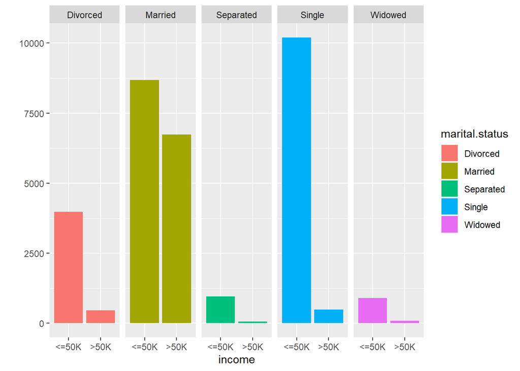

```r
qplot(income, data = census, fill = marital.status) + facet_grid (. ~ marital.status)
```

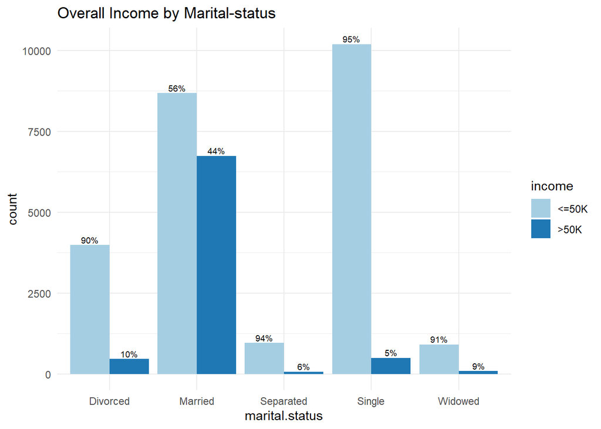

```r
  ggplot(data = status, aes(x = marital.status,y = count, fill = income)) +
    geom_bar(stat = "identity", position = position_dodge()) +
    geom_text(aes(label = label), vjust = -0.3, color="black",
              position = position_dodge(0.9), size = 2.5) +
    scale_fill_brewer(palette = "Paired") +
    theme_minimal() +
    ggtitle("Overall Income by Marital-status")
```

## **Race**

This variable doesn’t need much of a regrouping. I will just add “Amer-Indian-Eskimo” and “Asian-Pac-Islander” to the “Other” group because they don’t have a decent amount of instances.

```r
census$race = gsub('Amer-Indian-Eskimo', 'Other', census$race)
census$race = gsub('Asian-Pac-Islander', 'Other', census$race)
census$race = as.factor(census$race)
summary(census$race)
```

```
## Black Other White
##  3124  1621 27816
```

```r
races = data.frame(table(census$income, census$race))
names(races) = c('income', 'race', 'count')
races
```

```
##   income  race count
## 1  <=50K Black  2737
## 2   >50K Black   387
## 3  <=50K Other  1284
## 4   >50K Other   337
## 5  <=50K White 20699
## 6   >50K White  7117
```

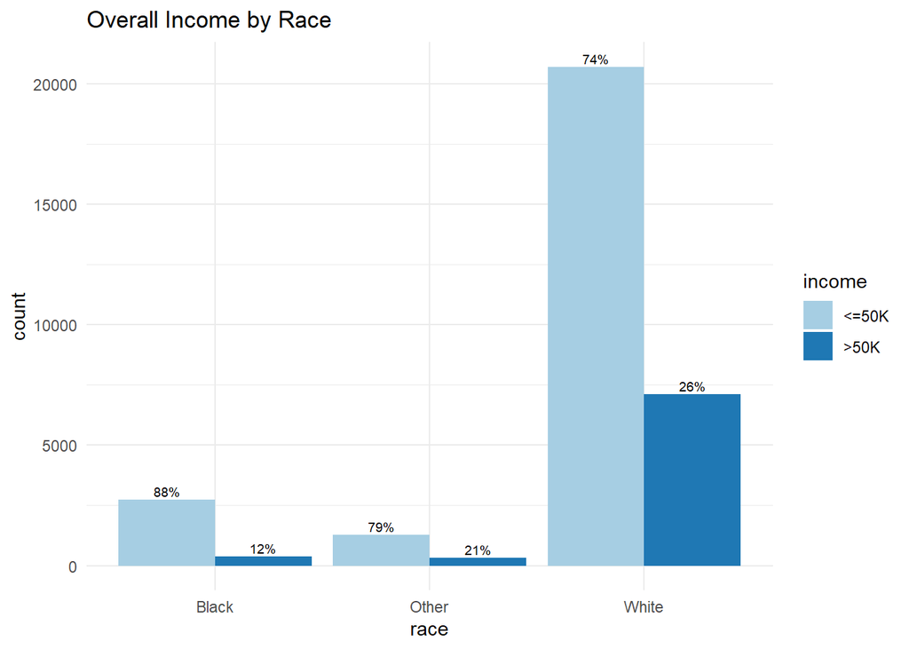

```r
ggplot(data = races, aes(x = race,y = count, fill = income)) +
  geom_bar(stat = "identity", position = position_dodge()) +
  geom_text(aes(label = label), vjust = -0.3, color="black",
            position = position_dodge(0.9), size = 2.5) +
  scale_fill_brewer(palette = "Paired") +
  theme_minimal() +
  ggtitle("Overall Income by Race")
```

- The barplot shows that the “White” group earns the most.

## **Capital Gain/Loss**

This variable contains a lot of “empty” values, which are equal to zero. Instead, a new variable will be created. *Capital-change* variable will describe the difference between gain and loss.

```r
census$capital.change = census$capital.gain - census$capital.loss
census$capital.gain = NULL
census$capital.loss = NULL
census = census[c(1,2,3,4,5,6,7,8,9,10,12,11)]
```

## **Native.country**

The last variable has the most groups so far. This must be changed. These groups will be retransformed into more general ones by their region:

```r
census$native.country = gsub('South', 'Other', census$native.country)
census$native.country = gsub('Japan', 'Other', census$native.country)

census$native.country = gsub('Vietnam', 'Asia', census$native.country)
census$native.country = gsub('Laos', 'Asia', census$native.country)
census$native.country = gsub('Cambodia', 'Asia', census$native.country)
census$native.country = gsub('Thailand', 'Asia', census$native.country)
census$native.country = gsub('China', 'Asia', census$native.country)
census$native.country = gsub('India', 'Asia', census$native.country)
census$native.country = gsub('Hong', 'Asia', census$native.country)
census$native.country = gsub('Iran', 'Asia', census$native.country)
census$native.country = gsub('Philippines', 'Asia', census$native.country)
census$native.country = gsub('Taiwan', 'Asia', census$native.country)

census$native.country = gsub('Canada', 'America', census$native.country)
census$native.country = gsub('Cuba', 'America', census$native.country)
census$native.country = gsub('Dominican-Republic', 'America', census$native.country)
census$native.country = gsub('Guatemala', 'America', census$native.country)
census$native.country = gsub('Haiti', 'America', census$native.country)
census$native.country = gsub('Honduras', 'America', census$native.country)
census$native.country = gsub('Jamaica', 'America', census$native.country)
census$native.country = gsub('Mexico', 'America', census$native.country)
census$native.country = gsub('Nicaragua', 'America', census$native.country)
census$native.country = gsub('Puerto-Rico', 'America', census$native.country)
census$native.country = gsub('El-Salvador', 'America', census$native.country)
census$native.country = gsub('United-States', 'America', census$native.country)
census$native.country = gsub('Ecuador', 'America', census$native.country)
census$native.country = gsub('Peru', 'America', census$native.country)
census$native.country = gsub('Columbia', 'America', census$native.country)
census$native.country = gsub('Trinadad&Tobago', 'America', census$native.country)
census$native.country = gsub('Outlying-US(Guam-USVI-etc)', 'America', census$native.country)

census$native.country = gsub('France', 'Europe', census$native.country)
census$native.country = gsub('Germany', 'Europe', census$native.country)
census$native.country = gsub('Greece', 'Europe', census$native.country)
census$native.country = gsub('Holand-Netherlands', 'Europe', census$native.country)
census$native.country = gsub('Italy', 'Europe', census$native.country)
census$native.country = gsub('Hungary', 'Europe', census$native.country)
census$native.country = gsub('Ireland', 'Europe', census$native.country)
census$native.country = gsub('Poland', 'Europe', census$native.country)
census$native.country = gsub('Portugal', 'Europe', census$native.country)
census$native.country = gsub('Scotland', 'Europe', census$native.country)
census$native.country = gsub('England', 'Europe', census$native.country)
census$native.country = gsub('Yugoslavia', 'Europe', census$native.country)

census$native.country = as.factor(census$native.country)

levels(census$native.country)[1] = 'Unknown'
census$native.country = gsub('Unknown', 'Other', census$native.country)

census$native.country = as.factor(census$native.country)

summary(census$native.country)
```

```
##                    America                       Asia
##                      30692                        609
##                     Europe                      Other
##                        521                        725
## Outlying-US(Guam-USVI-etc)
##                         14
```

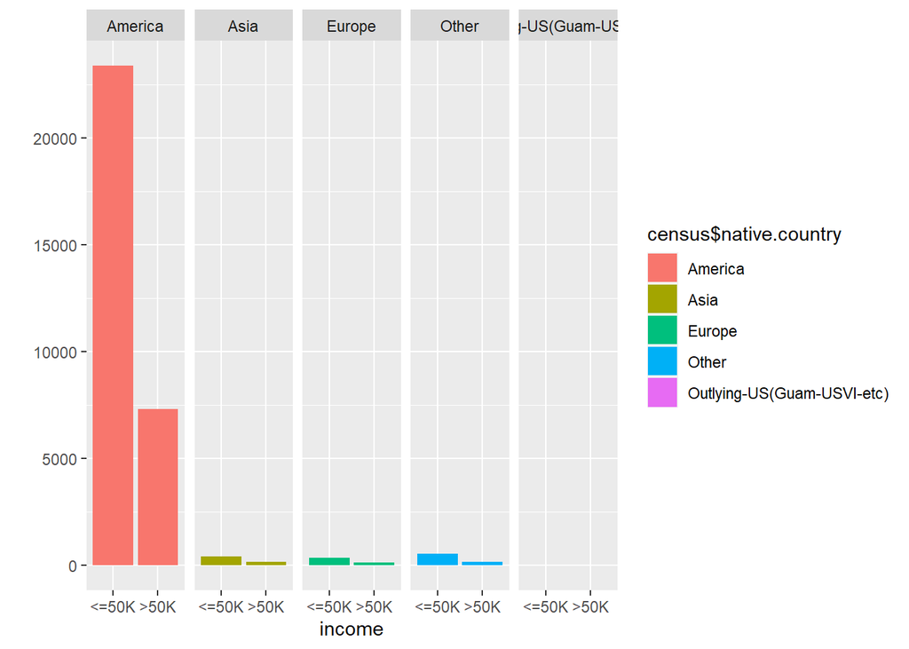

```r
qplot(income, data = census, fill = census$native.country) + facet_grid (. ~ census$native.country)
```

- The barplot shows that nearly all of the data were taken from America (United-States in general). That’s why this variable will be dropped. Relationship is dropped as well.

```r
census$native.country = NULL
census$relationship = NULL
census$sex = as.factor(census$sex)
census$income = as.factor(census$income)
```

This is the end of the preprocessing phase. This data set is now ready for modeling and classification. The summary now looks like this.

```r
summary(census)
```

```
##       age                workclass     education.num     marital.status
##  Min.   :17.00   Government   : 4351   Min.   : 1.00   Divorced : 4443
##  1st Qu.:28.00   Other        : 1857   1st Qu.: 9.00   Married  :15417
##  Median :37.00   Private      :22696   Median :10.00   Separated: 1025
##  Mean   :38.58   Self-Employed: 3657   Mean   :10.08   Single   :10683
##  3rd Qu.:48.00                         3rd Qu.:12.00   Widowed  :  993
##  Max.   :90.00                         Max.   :16.00
##         occupation       race           sex        hours.per.week
##  Blue-Collar :10062   Black: 3124   Female:10771   Min.   : 1.00
##  Other       : 1852   Other: 1621   Male  :21790   1st Qu.:40.00
##  Professional: 4140   White:27816                  Median :40.00
##  Sales       : 3650                                Mean   :40.44
##  Service     : 5021                                3rd Qu.:45.00
##  White-Collar: 7836                                Max.   :99.00
##  capital.change      income
##  Min.   :-4356.0   <=50K:24720
##  1st Qu.:    0.0   >50K : 7841
##  Median :    0.0
##  Mean   :  990.4
##  3rd Qu.:    0.0
##  Max.   :99999.0
```

# **Modeling**

As was stated above, the main idea is to classify whether the income is above or below 50k, which is a categorical variable. Confusion matrix will be used to get accuracy and missclassification rate. Since, the data set is prepared for the analysis I will use different models, such as:

1. Logistic Regression
2. Classification and Regression Tree(CART)
3. Random Forest
4. Naive Bayes Classification
5. K-nearest Neighbours(KNN)
6. Classification Based On Association Rules Algorithm(CBA)

## **Train/test Splitting**

Before modeling, the data has to be split. I will try different split ratio:

- 80/20 %
- 70/30 %
- 60/40 %

```r
size_1 = round(.8 * dim(census)[1])
census_train_1 = census[1:size_1,]
census_test_1 = census[-(1:size_1),]
```

```r
size_2 = round(.7 * dim(census)[1])
census_train_2 = census[1:size_2,]
census_test_2 = census[-(1:size_2),]
```

```r
size_3 = round(.6 * dim(census)[1])
census_train_3 = census[1:size_3,]
census_test_3 = census[-(1:size_3),]
```

## **Logistic regression**

Logistic Regression is used to model the probability of a certain class (*income* in this case). This regression is estimating the parameters of a logistic model to model a binary dependent variable.

### **80/20 %**

To begin with, I’m going to create the model with 80% on train and 20% on test division.

```r
logicregress_1 = glm(income ~ ., data = census_train_1, family = binomial('logit'))
summary(logicregress_1)
```

```
##
## Call:
## glm(formula = income ~ ., family = binomial("logit"), data = census_train_1)
##
## Deviance Residuals:
##     Min       1Q   Median       3Q      Max
## -4.6442  -0.5552  -0.2395  -0.0704   3.3274
##
## Coefficients:
##                           Estimate Std. Error z value Pr(>|z|)
## (Intercept)             -8.992e+00  1.865e-01 -48.204  < 2e-16 ***
## age                      2.637e-02  1.692e-03  15.588  < 2e-16 ***
## workclassOther          -1.402e+00  8.200e-01  -1.710  0.08732 .
## workclassPrivate         3.305e-02  5.503e-02   0.601  0.54816
## workclassSelf-Employed  -2.288e-01  7.140e-02  -3.204  0.00135 **
## education.num            3.078e-01  9.671e-03  31.831  < 2e-16 ***
## marital.statusMarried    2.085e+00  7.134e-02  29.232  < 2e-16 ***
## marital.statusSeparated -6.874e-02  1.709e-01  -0.402  0.68750
## marital.statusSingle    -4.800e-01  8.798e-02  -5.455 4.88e-08 ***
## marital.statusWidowed   -4.616e-02  1.660e-01  -0.278  0.78090
## occupationOther          9.579e-01  8.185e-01   1.170  0.24185
## occupationProfessional   7.458e-01  6.954e-02  10.725  < 2e-16 ***
## occupationSales          4.857e-01  6.563e-02   7.401 1.35e-13 ***
## occupationService        1.851e-01  6.844e-02   2.705  0.00684 **
## occupationWhite-Collar   7.588e-01  5.417e-02  14.009  < 2e-16 ***
## raceOther               -2.592e-01  1.180e-01  -2.197  0.02804 *
## raceWhite                2.012e-01  7.750e-02   2.597  0.00941 **
## sexMale                  3.946e-01  5.390e-02   7.320 2.48e-13 ***
## hours.per.week           3.025e-02  1.686e-03  17.939  < 2e-16 ***
## capital.change           2.382e-04  9.207e-06  25.873  < 2e-16 ***
## ---
## Signif. codes:  0 '***' 0.001 '**' 0.01 '*' 0.05 '.' 0.1 ' ' 1
##
## (Dispersion parameter for binomial family taken to be 1)
##
##     Null deviance: 28685  on 26048  degrees of freedom
## Residual deviance: 17970  on 26029  degrees of freedom
## AIC: 18010
##
## Number of Fisher Scoring iterations: 6
```

```r
confint(logicregress_1)
```

```
##                                 2.5 %        97.5 %
## (Intercept)             -9.3602284493 -8.6289155853
## age                      0.0230606737  0.0296934321
## workclassOther          -3.0065079038  0.1875902523
## workclassPrivate        -0.0745727891  0.1411610457
## workclassSelf-Employed  -0.3687787937 -0.0888877553
## education.num            0.2889778070  0.3268910559
## marital.statusMarried    1.9469038772  2.2266060527
## marital.statusSeparated -0.4140196596  0.2571196336
## marital.statusSingle    -0.6522444551 -0.3072593110
## marital.statusWidowed   -0.3800082196  0.2715186149
## occupationOther         -0.6323983965  2.5562857086
## occupationProfessional   0.6095481927  0.8821534668
## occupationSales          0.3569075098  0.6141926135
## occupationService        0.0504530086  0.3187608587
## occupationWhite-Collar   0.6527427112  0.8650904275
## raceOther               -0.4910557146 -0.0283836653
## raceWhite                0.0506315325  0.3544901094
## sexMale                  0.2890907550  0.5004068158
## hours.per.week           0.0269505159  0.0335611160
## capital.change           0.0002204333  0.0002565297
```

The logistic regression appears to fit the data well. However, to explore the other possible results, I will try the backward and forward selection as well.

- Backward Selection

```r
step(m_full_1, trace = F, scope = list(lower=formula(m_null_1), upper=formula(m_full_1)),
     direction = 'backward')
```

```
##
## Call:  glm(formula = income ~ age + workclass + education.num + marital.status +
##     occupation + race + sex + hours.per.week + capital.change,
##     family = binomial("logit"), data = census_train_1)
##
## Coefficients:
##             (Intercept)                      age           workclassOther
##              -8.9923954                0.0263741               -1.4018568
##        workclassPrivate   workclassSelf-Employed            education.num
##               0.0330468               -0.2287820                0.3078456
##   marital.statusMarried  marital.statusSeparated     marital.statusSingle
##               2.0853004               -0.0687431               -0.4799716
##   marital.statusWidowed          occupationOther   occupationProfessional
##              -0.0461617                0.9579059                0.7458100
##         occupationSales        occupationService   occupationWhite-Collar
##               0.4857274                0.1850938                0.7588389
##               raceOther                raceWhite                  sexMale
##              -0.2592154                0.2012488                0.3945673
##          hours.per.week           capital.change
##               0.0302483                0.0002382
##
## Degrees of Freedom: 26048 Total (i.e. Null);  26029 Residual
## Null Deviance:       28690
## Residual Deviance: 17970     AIC: 18010
```

- Forward Selection

```r
step(m_full_1, trace = F, scope = list(lower=formula(m_null_1), upper=formula(m_full_1)),
     direction = 'forward')
```

```
##
## Call:  glm(formula = income ~ age + workclass + education.num + marital.status +
##     occupation + race + sex + hours.per.week + capital.change,
##     family = binomial("logit"), data = census_train_1)
##
## Coefficients:
##             (Intercept)                      age           workclassOther
##              -8.9923954                0.0263741               -1.4018568
##        workclassPrivate   workclassSelf-Employed            education.num
##               0.0330468               -0.2287820                0.3078456
##   marital.statusMarried  marital.statusSeparated     marital.statusSingle
##               2.0853004               -0.0687431               -0.4799716
##   marital.statusWidowed          occupationOther   occupationProfessional
##              -0.0461617                0.9579059                0.7458100
##         occupationSales        occupationService   occupationWhite-Collar
##               0.4857274                0.1850938                0.7588389
##               raceOther                raceWhite                  sexMale
##              -0.2592154                0.2012488                0.3945673
##          hours.per.week           capital.change
##               0.0302483                0.0002382
##
## Degrees of Freedom: 26048 Total (i.e. Null);  26029 Residual
## Null Deviance:       28690
## Residual Deviance: 17970     AIC: 18010
```

Both backward and forward selection algorithms give the same model as the initial fit, meaning that the original model will be chosen.

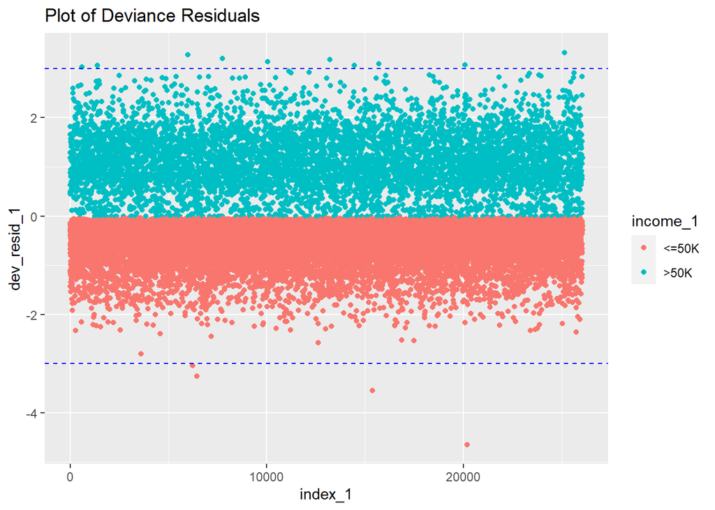

```r
index_1 = 1:dim(census_train_1)[1]
dev_resid_1 = residuals(logicregress_1)
income_1 = census_train_1$income
dff_1 = data.frame(index_1, dev_resid_1, income_1)

ggplot(dff_1, aes(x = index_1, y = dev_resid_1, color = income_1)) +
  ggtitle('Plot of Deviance Residuals') + geom_point() +
  geom_hline(yintercept = 3, linetype = 'dashed', color = 'blue') +
  geom_hline(yintercept = -3, linetype = 'dashed', color = 'blue')
```

This regression is modeling the probability that an individual makes more than 50K. Meaning that the response, which is higher than 0 indicates higher chance of making > 50k. A confusion matrix is presented to show how well the model predicts *income*.

```r
prob_1 = predict(logicregress_1, census_test_1, type = 'response')
pred_1 = rep('<=50K', length(prob_1))
pred_1[prob_1>=.5] = '>50K'

cf_1 = table(pred_1, census_test_1$income)
cf_1
```

```
##
## pred_1  <=50K >50K
##   <=50K  4558  709
##   >50K    354  891
```

The prediction result has an accuracy of 83.67% and a missclassification rate of 16.33%.

### **70/30 %**

The same classifier will be created, using the 70/30% split this time.

```r
logicregress_2 = glm(income ~ ., data = census_train_2, family = binomial('logit'))
summary(logicregress_2)
```

```
##
## Call:
## glm(formula = income ~ ., family = binomial("logit"), data = census_train_2)
##
## Deviance Residuals:
##     Min       1Q   Median       3Q      Max
## -4.6012  -0.5574  -0.2413  -0.0729   3.2696
##
## Coefficients:
##                           Estimate Std. Error z value Pr(>|z|)
## (Intercept)             -8.968e+00  1.993e-01 -45.007  < 2e-16 ***
## age                      2.615e-02  1.804e-03  14.500  < 2e-16 ***
## workclassOther          -6.029e-01  1.068e+00  -0.565  0.57225
## workclassPrivate         1.895e-02  5.869e-02   0.323  0.74674
## workclassSelf-Employed  -2.084e-01  7.602e-02  -2.742  0.00611 **
## education.num            3.045e-01  1.032e-02  29.508  < 2e-16 ***
## marital.statusMarried    2.113e+00  7.671e-02  27.548  < 2e-16 ***
## marital.statusSeparated -8.808e-03  1.816e-01  -0.048  0.96132
## marital.statusSingle    -4.546e-01  9.423e-02  -4.825 1.40e-06 ***
## marital.statusWidowed   -6.032e-02  1.796e-01  -0.336  0.73700
## occupationOther          2.048e-01  1.067e+00   0.192  0.84781
## occupationProfessional   7.604e-01  7.424e-02  10.243  < 2e-16 ***
## occupationSales          4.428e-01  6.999e-02   6.327 2.50e-10 ***
## occupationService        2.196e-01  7.289e-02   3.013  0.00259 **
## occupationWhite-Collar   7.861e-01  5.783e-02  13.592  < 2e-16 ***
## raceOther               -2.319e-01  1.255e-01  -1.848  0.06455 .
## raceWhite                2.099e-01  8.260e-02   2.541  0.01106 *
## sexMale                  3.668e-01  5.732e-02   6.398 1.57e-10 ***
## hours.per.week           3.034e-02  1.800e-03  16.852  < 2e-16 ***
## capital.change           2.335e-04  9.717e-06  24.027  < 2e-16 ***
## ---
## Signif. codes:  0 '***' 0.001 '**' 0.01 '*' 0.05 '.' 0.1 ' ' 1
##
## (Dispersion parameter for binomial family taken to be 1)
##
##     Null deviance: 25044  on 22792  degrees of freedom
## Residual deviance: 15773  on 22773  degrees of freedom
## AIC: 15813
##
## Number of Fisher Scoring iterations: 6
```

```r
confint(logicregress_2)
```

```
##                                 2.5 %        97.5 %
## (Intercept)             -9.3612712992 -8.5801066189
## age                      0.0226222078  0.0296935475
## workclassOther          -2.5876884176  1.4586829411
## workclassPrivate        -0.0958093170  0.1342670680
## workclassSelf-Employed  -0.3575014806 -0.0594915682
## education.num            0.2843602818  0.3248121909
## marital.statusMarried    1.9645889311  2.2653745479
## marital.statusSeparated -0.3762411060  0.3371380880
## marital.statusSingle    -0.6391046946 -0.2695909230
## marital.statusWidowed   -0.4224585932  0.2828579830
## occupationOther         -1.8610135249  2.1832095960
## occupationProfessional   0.6149330689  0.9059608193
## occupationSales          0.3054142642  0.5798195417
## occupationService        0.0761940956  0.3619714619
## occupationWhite-Collar   0.6728010188  0.8995247949
## raceOther               -0.4784355182  0.0135005331
## raceWhite                0.0494252138  0.3733182881
## sexMale                  0.2545891175  0.4793245355
## hours.per.week           0.0268203169  0.0338786127
## capital.change           0.0002147368  0.0002528322
```

Nearly same results were achieved, which means that the original model will be used for classification.

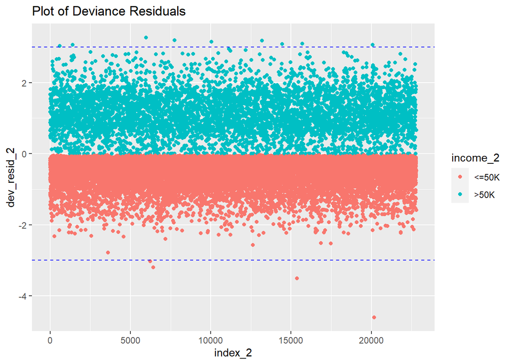

```r
index_2 = 1:dim(census_train_2)[1]
dev_resid_2 = residuals(logicregress_2)
income_2 = census_train_2$income
dff_2 = data.frame(index_2, dev_resid_2, income_2)

ggplot(dff_2, aes(x = index_2, y = dev_resid_2, color = income_2)) +
  ggtitle('Plot of Deviance Residuals') + geom_point() +
  geom_hline(yintercept = 3, linetype = 'dashed', color = 'blue') +
  geom_hline(yintercept = -3, linetype = 'dashed', color = 'blue')
```

It’s hard to determine whether this split is better than 80/20% by viewing the plot. However, the confusion matrix will show the diiference.

```r
prob_2 = predict(logicregress_2, census_test_2, type = 'response')
pred_2 = rep('<=50K', length(prob_2))
pred_2[prob_2>=.5] = '>50K'

cf_2 = table(pred_2, census_test_2$income)
cf_2
```

```
##
## pred_2  <=50K >50K
##   <=50K  6872 1044
##   >50K    492 1360
```

Interestingly enough, the classification results have improved. Accuracy has increased to 84.27% and a missclassification rate has decreased to 15.73%.

### **60/40 %**

70/30 % split has shown the best results so far. But there’s a probability that the 60/40 % split will do better in classification.

```r
logicregress_3 = glm(income ~ ., data = census_train_3, family = binomial('logit'))
summary(logicregress_3)
```

```
##
## Call:
## glm(formula = income ~ ., family = binomial("logit"), data = census_train_3)
##
## Deviance Residuals:
##     Min       1Q   Median       3Q      Max
## -3.4976  -0.5585  -0.2429  -0.0740   3.2561
##
## Coefficients:
##                           Estimate Std. Error z value Pr(>|z|)
## (Intercept)             -8.8895044  0.2153086 -41.287  < 2e-16 ***
## age                      0.0265106  0.0019420  13.651  < 2e-16 ***
## workclassOther           0.2572562  1.5004977   0.171  0.86387
## workclassPrivate         0.0173155  0.0634037   0.273  0.78478
## workclassSelf-Employed  -0.2032758  0.0821409  -2.475  0.01333 *
## education.num            0.3019564  0.0111390  27.108  < 2e-16 ***
## marital.statusMarried    2.0714414  0.0823602  25.151  < 2e-16 ***
## marital.statusSeparated -0.0222721  0.1951725  -0.114  0.90915
## marital.statusSingle    -0.4830167  0.1015673  -4.756 1.98e-06 ***
## marital.statusWidowed   -0.1020810  0.1947578  -0.524  0.60018
## occupationOther         -0.6362364  1.5000761  -0.424  0.67147
## occupationProfessional   0.7175960  0.0803059   8.936  < 2e-16 ***
## occupationSales          0.4110517  0.0753266   5.457 4.84e-08 ***
## occupationService        0.2148316  0.0785049   2.737  0.00621 **
## occupationWhite-Collar   0.7674027  0.0623448  12.309  < 2e-16 ***
## raceOther               -0.2645780  0.1367963  -1.934  0.05310 .
## raceWhite                0.2126388  0.0902445   2.356  0.01846 *
## sexMale                  0.3807961  0.0618233   6.159 7.30e-10 ***
## hours.per.week           0.0297153  0.0019424  15.298  < 2e-16 ***
## capital.change           0.0002313  0.0000105  22.038  < 2e-16 ***
## ---
## Signif. codes:  0 '***' 0.001 '**' 0.01 '*' 0.05 '.' 0.1 ' ' 1
##
## (Dispersion parameter for binomial family taken to be 1)
##
##     Null deviance: 21473  on 19536  degrees of freedom
## Residual deviance: 13567  on 19517  degrees of freedom
## AIC: 13607
##
## Number of Fisher Scoring iterations: 6
```

```r
confint(logicregress_3)
```

```
##                                 2.5 %       97.5 %
## (Intercept)             -9.3144033342 -8.470329775
## age                      0.0227079800  0.030321064
## workclassOther          -2.2877287267  2.958247780
## workclassPrivate        -0.1066415663  0.141924694
## workclassSelf-Employed  -0.3643416549 -0.042322596
## education.num            0.2802382411  0.323905370
## marital.statusMarried    1.9119122659  2.234857615
## marital.statusSeparated -0.4182794494  0.348601700
## marital.statusSingle    -0.6818723517 -0.283572544
## marital.statusWidowed   -0.4961653122  0.268849351
## occupationOther         -3.3430278020  1.900406323
## occupationProfessional   0.5602222879  0.875046475
## occupationSales          0.2631300277  0.558444323
## occupationService        0.0603321732  0.368122629
## occupationWhite-Collar   0.6453074720  0.889715815
## raceOther               -0.5334359922  0.002983329
## raceWhite                0.0375105423  0.391393293
## sexMale                  0.2598459406  0.502225000
## hours.per.week           0.0259171077  0.033532417
## capital.change           0.0002111278  0.000252281
```

The third classifier appears to be suitable for fitting as well. So, the original classifier will be used as well.

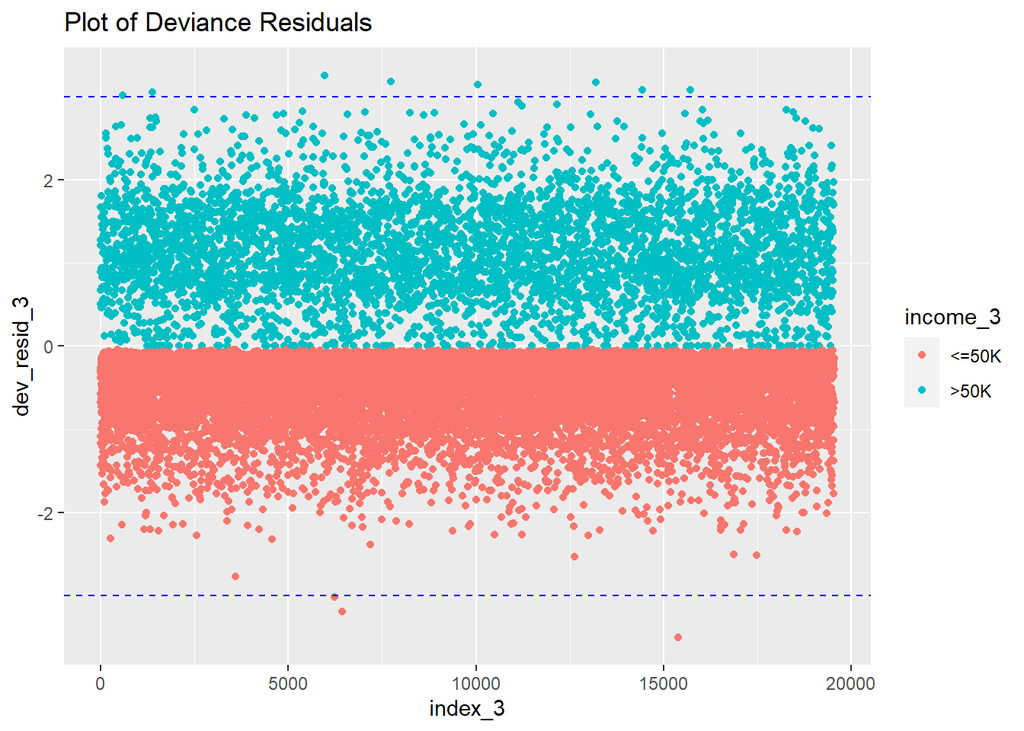

```r
index_3 = 1:dim(census_train_3)[1]
dev_resid_3 = residuals(logicregress_3)
income_3 = census_train_3$income
dff_3 = data.frame(index_3, dev_resid_3, income_3)

ggplot(dff_3, aes(x = index_3, y = dev_resid_3, color = income_3)) +
  ggtitle('Plot of Deviance Residuals') + geom_point() +
  geom_hline(yintercept = 3, linetype = 'dashed', color = 'blue') +
  geom_hline(yintercept = -3, linetype = 'dashed', color = 'blue')
```

The plot shows the results a bit closer to the centre. Although, this doesn’t tell much of a difference. The confusion matrix will show the truth.

```r
prob_3 = predict(logicregress_3, census_test_3, type = 'response')
pred_3 = rep('<=50K', length(prob_3))
pred_3[prob_3>=.5] = '>50K'

cf_3 = table(pred_3, census_test_3$income)
cf_3
```

```
##
## pred_3  <=50K >50K
##   <=50K  9196 1398
##   >50K    650 1780
```

The 60/40 % split didn’t achieve better results, giving the similar ones. Accuracy remains on 84.27% mark and a missclassification rate of 15.73% holds the same position.

## **Classification and Regression Tree(CART)**

Now, I’m going to “grow” a classification tree on the training data set. The CART model is obtained by recursively partitioning the data space and fitting a simple prediction model within each partition.

### **80/20 %**

The first tree will be created with 80/20 % split ratio.

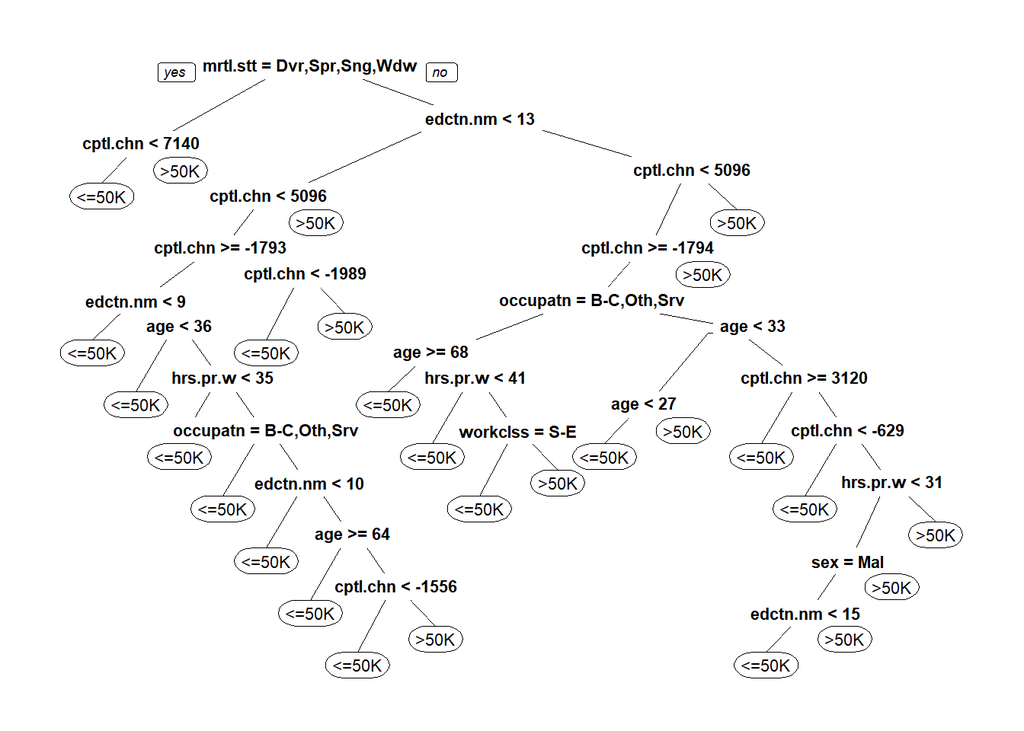

```r
tree_1 = rpart(income ~ ., data = census_train_1, method = 'class', cp = 1e-3)

prp(tree_1,varlen=8, cex = 0.7)
```

```r
tree_1.pred.prob = predict(tree_1, newdata = census_test_1, type = 'prob')
tree_1.pred = predict(tree_1, newdata = census_test_1, type = 'class')
confusionMatrix(tree_1.pred,census_test_1$income)
```

```
## Confusion Matrix and Statistics
##
##           Reference
## Prediction <=50K >50K
##      <=50K  4640  642
##      >50K    272  958
##
##                Accuracy : 0.8596
##                  95% CI : (0.851, 0.868)
##     No Information Rate : 0.7543
##     P-Value [Acc > NIR] : < 2.2e-16
##
##                   Kappa : 0.5893
##
##  Mcnemar's Test P-Value : < 2.2e-16
##
##             Sensitivity : 0.9446
##             Specificity : 0.5988
##          Pos Pred Value : 0.8785
##          Neg Pred Value : 0.7789
##              Prevalence : 0.7543
##          Detection Rate : 0.7125
##    Detection Prevalence : 0.8111
##       Balanced Accuracy : 0.7717
##
##        'Positive' Class : <=50K
##
```

The confusion matrix shows better results, than the ones achieved from classifiers above. The prediction result has an accuracy of 85.96% and a missclassification rate of 14.04%

### **70/30 %**

The practice has shown, that 70/30 % split is the best for analysis.

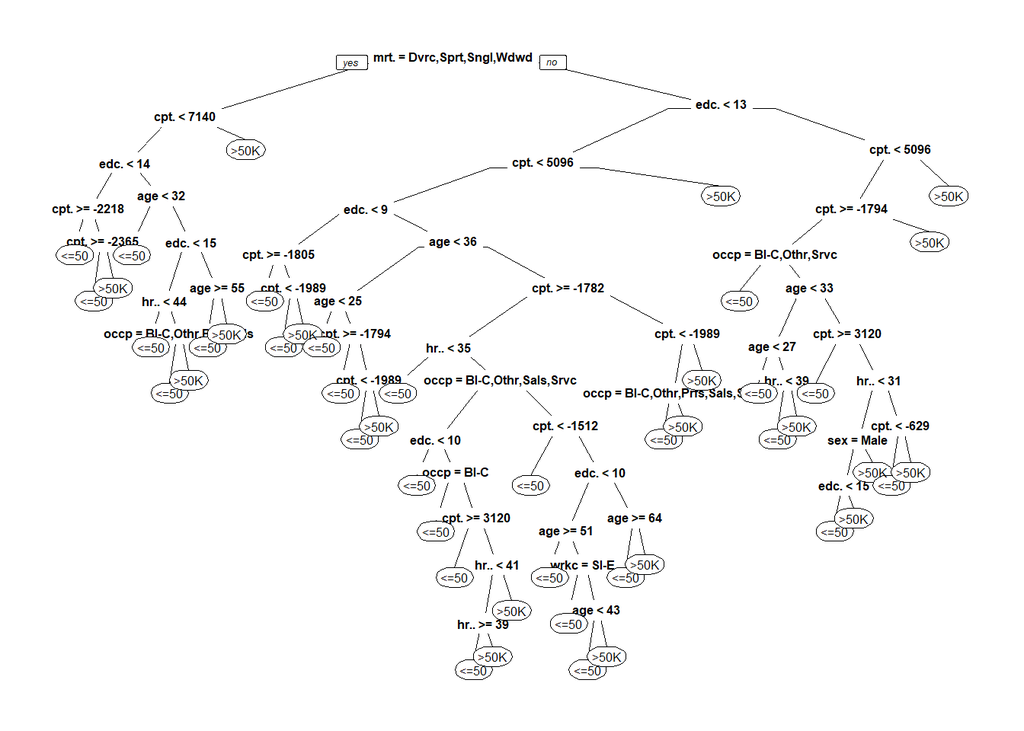

```r
tree_2 = rpart(income ~ ., data = census_train_2, method = 'class', cp = 1e-3)
prp(tree_2,varlen=4, faclen = 4, fallen.leaves = FALSE, tweak = 1.7, compress = FALSE, branch = 0.3, gap = 1.5, cex = 0.3)
```

```r
tree_2.pred.prob = predict(tree_2, newdata = census_test_2, type = 'prob')
tree_2.pred = predict(tree_2, newdata = census_test_2, type = 'class')
confusionMatrix(tree_2.pred,census_test_2$income)
```

```
## Confusion Matrix and Statistics
##
##           Reference
## Prediction <=50K >50K
##      <=50K  6945  940
##      >50K    419 1464
##
##                Accuracy : 0.8609
##                  95% CI : (0.8539, 0.8677)
##     No Information Rate : 0.7539
##     P-Value [Acc > NIR] : < 2.2e-16
##
##                   Kappa : 0.5956
##
##  Mcnemar's Test P-Value : < 2.2e-16
##
##             Sensitivity : 0.9431
##             Specificity : 0.6090
##          Pos Pred Value : 0.8808
##          Neg Pred Value : 0.7775
##              Prevalence : 0.7539
##          Detection Rate : 0.7110
##    Detection Prevalence : 0.8072
##       Balanced Accuracy : 0.7760
##
##        'Positive' Class : <=50K
##
```

As was expected, the results have improved. Prediction accuracy is now on the 86.09% mark and a missclassification rate is 13.91%.

### **60/40 %**

Previously, this split hasn’t made much of a difference. However, it was used in the completely another classifier.

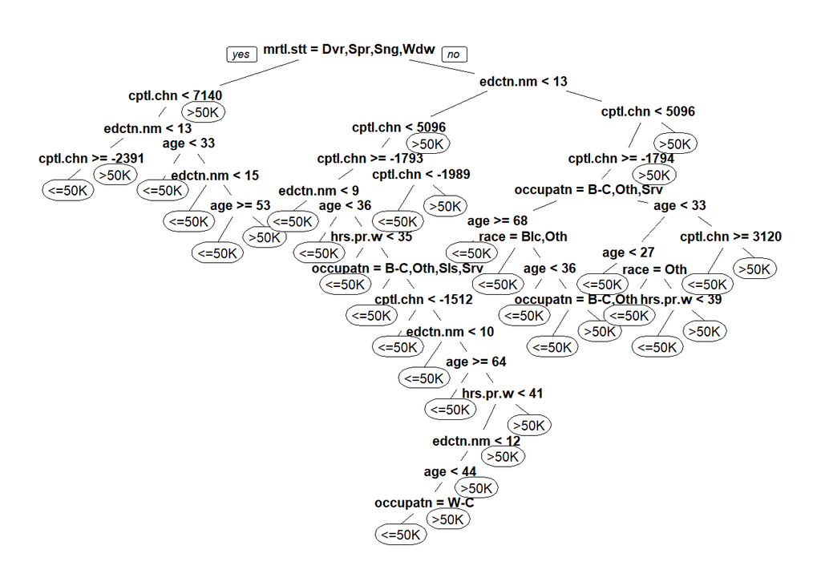

```r
tree_3 = rpart(income ~ ., data = census_train_3, method = 'class', cp = 1e-3)
prp(tree_3,varlen=8, cex = 0.7)
```

```r
tree_3.pred.prob = predict(tree_3, newdata = census_test_3, type = 'prob')
tree_3.pred = predict(tree_3, newdata = census_test_3, type = 'class')

confusionMatrix(tree_3.pred,census_test_3$income)
```

```
## Confusion Matrix and Statistics
##
##           Reference
## Prediction <=50K >50K
##      <=50K  9374 1366
##      >50K    472 1812
##
##                Accuracy : 0.8589
##                  95% CI : (0.8528, 0.8648)
##     No Information Rate : 0.756
##     P-Value [Acc > NIR] : < 2.2e-16
##
##                   Kappa : 0.5772
##
##  Mcnemar's Test P-Value : < 2.2e-16
##
##             Sensitivity : 0.9521
##             Specificity : 0.5702
##          Pos Pred Value : 0.8728
##          Neg Pred Value : 0.7933
##              Prevalence : 0.7560
##          Detection Rate : 0.7197
##    Detection Prevalence : 0.8246
##       Balanced Accuracy : 0.7611
##
##        'Positive' Class : <=50K
##
```

This split has changed the results. However, it made them worse, than the 70/30 % analog. Accuracy has decreased to 85.89% and a missclassification rate has increased to 14.11%.

## **Random Forest**

Random Forest is an another kind of tree classificators. It improves predictive accuracy by generating a large number of bootstrapped trees. Final predicted outcome is attained by combining the results across all of the trees. Which means, that better results are expected.

### **80/20 %**

The first classifier will have the 80/20 % split.

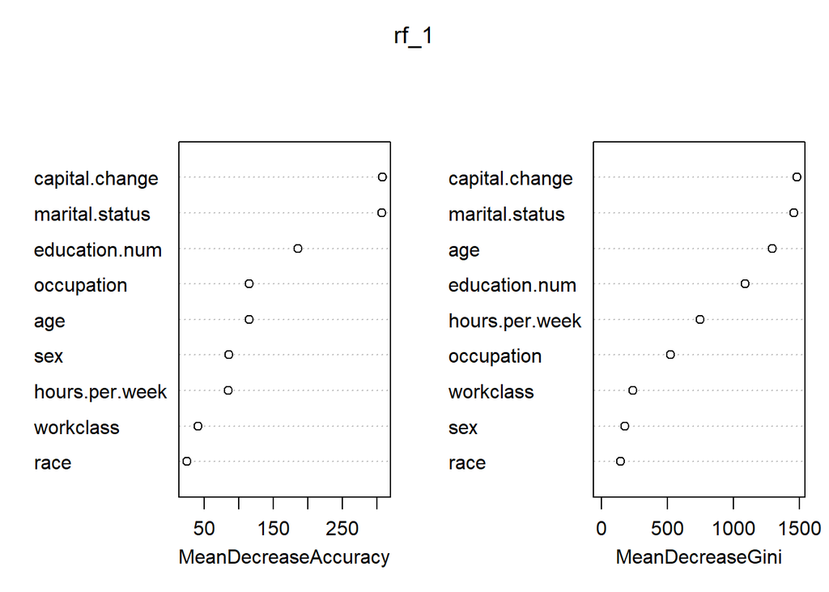

```r
set.seed(2)
rf_1 = randomForest(income ~ ., data = census_train_1, importance = TRUE, ntree = 1000)
varImpPlot(rf_1)
```

```r
rf_1.pred.prob = predict(rf_1, newdata = census_test_1, type = 'prob')
rf_1.pred = predict(rf_1, newdata = census_test_1, type = 'class')
confusionMatrix(rf_1.pred,census_test_1$income)
```

```
## Confusion Matrix and Statistics
##
##           Reference
## Prediction <=50K >50K
##      <=50K  4612  606
##      >50K    300  994
##
##                Accuracy : 0.8609
##                  95% CI : (0.8522, 0.8692)
##     No Information Rate : 0.7543
##     P-Value [Acc > NIR] : < 2.2e-16
##
##                   Kappa : 0.5988
##
##  Mcnemar's Test P-Value : < 2.2e-16
##
##             Sensitivity : 0.9389
##             Specificity : 0.6212
##          Pos Pred Value : 0.8839
##          Neg Pred Value : 0.7682
##              Prevalence : 0.7543
##          Detection Rate : 0.7082
##    Detection Prevalence : 0.8013
##       Balanced Accuracy : 0.7801
##
##        'Positive' Class : <=50K
##
```

Random Forest has performed nearly better, than CRAN by showing prediction accuracy of 86.09% and a missclassification rate of 13.91%.

### **70/30 %**

This split is expected to improve the accuracy.

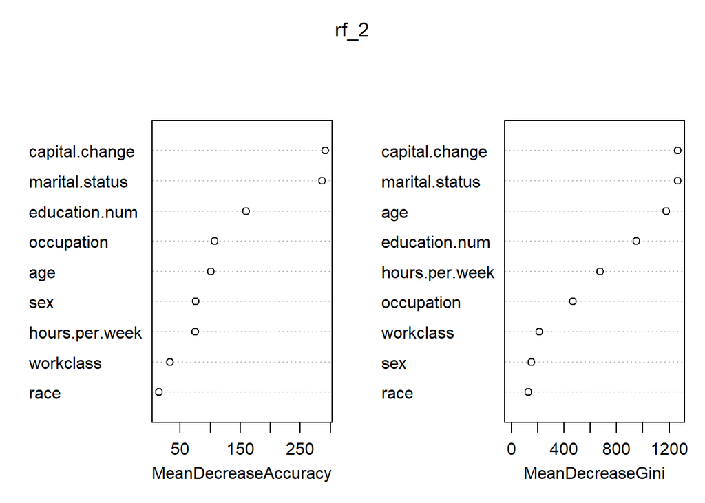

```r
set.seed(22)
rf_2 = randomForest(income ~ ., data = census_train_2, importance = TRUE, ntree = 1000)
varImpPlot(rf_2)
```

```r
rf_2.pred.prob = predict(rf_2, newdata = census_test_2, type = 'prob')
rf_2.pred = predict(rf_2, newdata = census_test_2, type = 'class')
confusionMatrix(rf_2.pred,census_test_2$income)
```

```
## Confusion Matrix and Statistics
##
##           Reference
## Prediction <=50K >50K
##      <=50K  6935  923
##      >50K    429 1481
##
##                Accuracy : 0.8616
##                  95% CI : (0.8546, 0.8684)
##     No Information Rate : 0.7539
##     P-Value [Acc > NIR] : < 2.2e-16
##
##                   Kappa : 0.5993
##
##  Mcnemar's Test P-Value : < 2.2e-16
##
##             Sensitivity : 0.9417
##             Specificity : 0.6161
##          Pos Pred Value : 0.8825
##          Neg Pred Value : 0.7754
##              Prevalence : 0.7539
##          Detection Rate : 0.7100
##    Detection Prevalence : 0.8045
##       Balanced Accuracy : 0.7789
##
##        'Positive' Class : <=50K
##
```

The prediction accuracy has increased to 86.16% and a missclassifiation rate has decreased to 13.84%.

### **60/40 %**

The 70/30 % split shows pleasant results. But does this mean that higher division could score better as well?

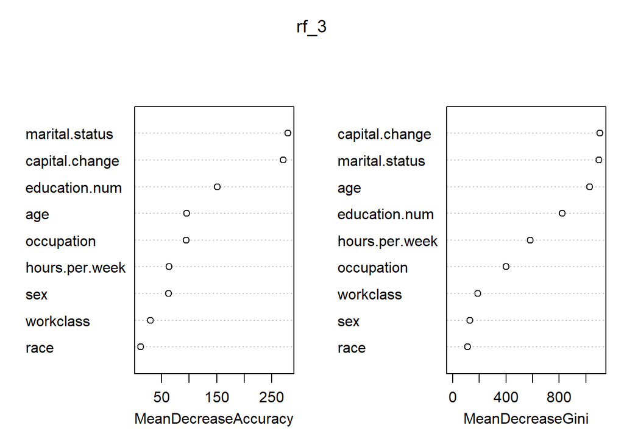

```r
set.seed(222)
rf_3 = randomForest(income ~ ., data = census_train_3, importance = TRUE, ntree = 1000)
varImpPlot(rf_3)
```

```r
rf_3.pred.prob = predict(rf_3, newdata = census_test_3, type = 'prob')
rf_3.pred = predict(rf_3, newdata = census_test_3, type = 'class')
confusionMatrix(rf_3.pred,census_test_3$income)
```

```
## Confusion Matrix and Statistics
##
##           Reference
## Prediction <=50K >50K
##      <=50K  9225 1192
##      >50K    621 1986
##
##                Accuracy : 0.8608
##                  95% CI : (0.8547, 0.8667)
##     No Information Rate : 0.756
##     P-Value [Acc > NIR] : < 2.2e-16
##
##                   Kappa : 0.5982
##
##  Mcnemar's Test P-Value : < 2.2e-16
##
##             Sensitivity : 0.9369
##             Specificity : 0.6249
##          Pos Pred Value : 0.8856
##          Neg Pred Value : 0.7618
##              Prevalence : 0.7560
##          Detection Rate : 0.7083
##    Detection Prevalence : 0.7998
##       Balanced Accuracy : 0.7809
##
##        'Positive' Class : <=50K
##
```

Unfortunately, the classifier didn’t improve. Prediction accuracy is 86.08% and missclassification rate is 13.92%.

## **Naive Bayes Classification**

Naive Bayes comes from a simple probabilistic classifier family, based on applying Bayes’theorem with strong (naive) independence assumptions between the features

### **80/20 %**

As always, the first classifier will be tested with 80/20 % split.

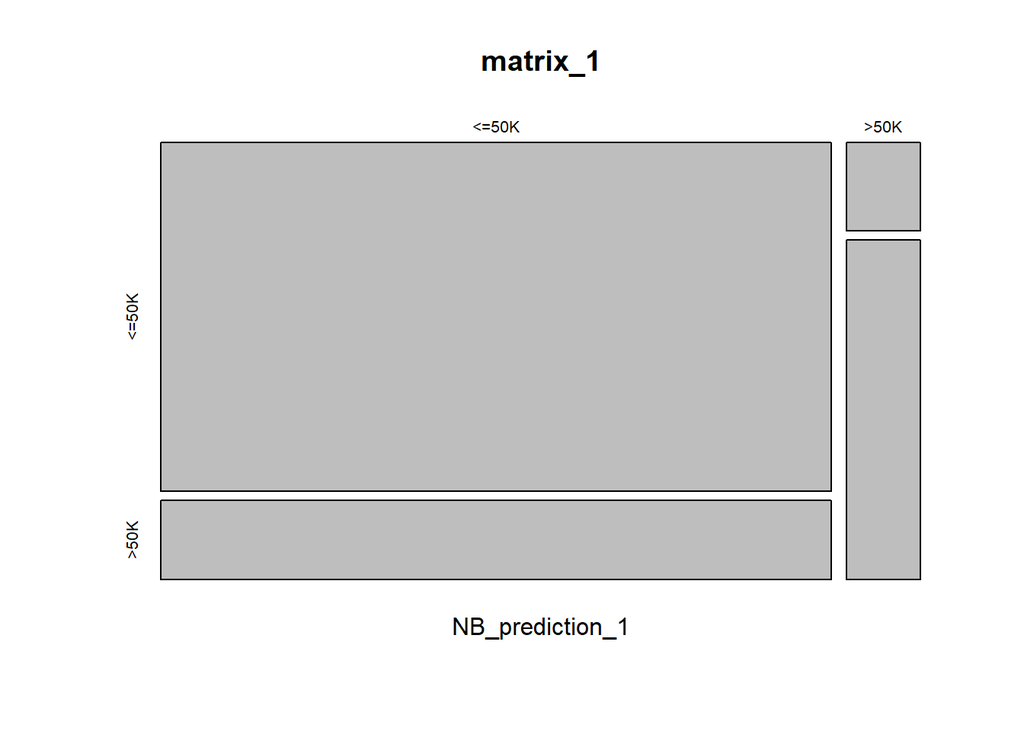

```r
NB_model_1 = naiveBayes(income~.,data = census_train_1)
NB_prediction_1 = predict(NB_model_1,census_test_1)
matrix_1 = table(NB_prediction_1, census_test_1$income)
plot(matrix_1)
```

```r
confusionMatrix(NB_prediction_1,census_test_1$income)
```

```
## Confusion Matrix and Statistics
##
##           Reference
## Prediction <=50K >50K
##      <=50K  4779 1088
##      >50K    133  512
##
##                Accuracy : 0.8125
##                  95% CI : (0.8028, 0.8219)
##     No Information Rate : 0.7543
##     P-Value [Acc > NIR] : < 2.2e-16
##
##                   Kappa : 0.3667
##
##  Mcnemar's Test P-Value : < 2.2e-16
##
##             Sensitivity : 0.9729
##             Specificity : 0.3200
##          Pos Pred Value : 0.8146
##          Neg Pred Value : 0.7938
##              Prevalence : 0.7543
##          Detection Rate : 0.7339
##    Detection Prevalence : 0.9010
##       Balanced Accuracy : 0.6465
##
##        'Positive' Class : <=50K
##
```

This simple model didn’t perform significantly. Accuracy hasn’t improved, 81.25% was achieved and missclassification rate is 18.75%

### **70/30 %**

Eventhough the first split wasn’t as productive as expected, the 70/30 % can make a difference.

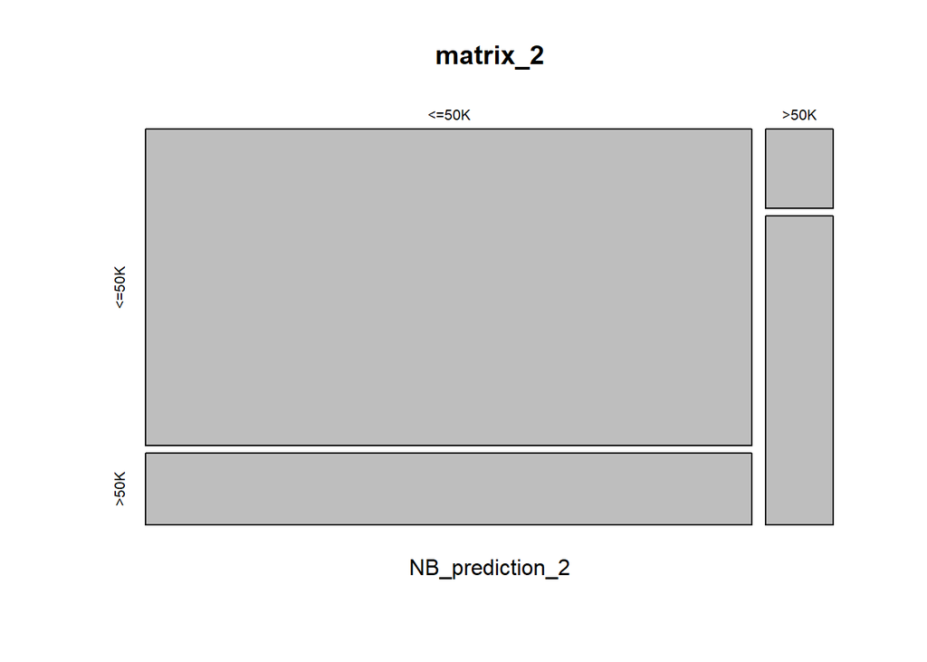

```r
NB_model_2 = naiveBayes(income~.,data = census_train_2)
NB_prediction_2 = predict(NB_model_2,census_test_2)
matrix_2 = table(NB_prediction_2, census_test_2$income)
plot(matrix_2)
```

```r
confusionMatrix(NB_prediction_2,census_test_2$income)
```

```
## Confusion Matrix and Statistics
##
##           Reference
## Prediction <=50K >50K
##      <=50K  7165 1625
##      >50K    199  779
##
##                Accuracy : 0.8133
##                  95% CI : (0.8054, 0.821)
##     No Information Rate : 0.7539
##     P-Value [Acc > NIR] : < 2.2e-16
##
##                   Kappa : 0.3712
##
##  Mcnemar's Test P-Value : < 2.2e-16
##
##             Sensitivity : 0.9730
##             Specificity : 0.3240
##          Pos Pred Value : 0.8151
##          Neg Pred Value : 0.7965
##              Prevalence : 0.7539
##          Detection Rate : 0.7335
##    Detection Prevalence : 0.8999
##       Balanced Accuracy : 0.6485
##
##        'Positive' Class : <=50K
##
```

A minor increase in accuracy was achieved - 81.33%, with a missclassification rate of 18.67%.

### **60/40 %**

This split is the last chance of improving the classifier statistics.

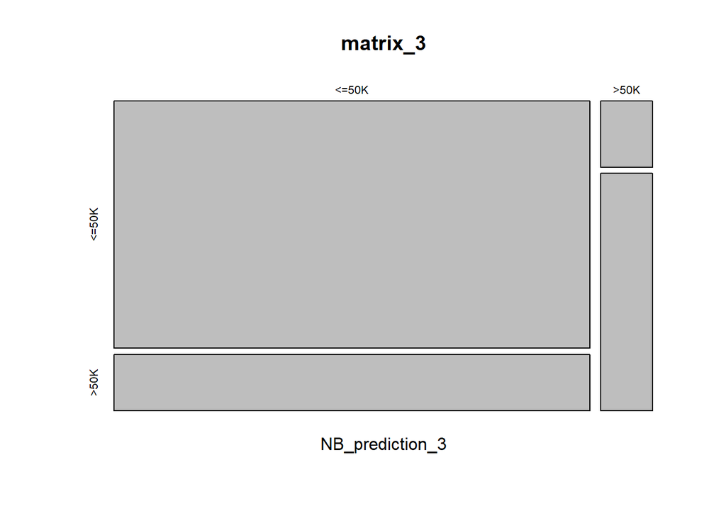

```r
NB_model_3 = naiveBayes(income~.,data = census_train_3)
NB_prediction_3 = predict(NB_model_3,census_test_3)
matrix_3 = table(NB_prediction_3, census_test_3$income)
plot(matrix_3)
```

```r
confusionMatrix(NB_prediction_3,census_test_3$income)
```

```
## Confusion Matrix and Statistics
##
##           Reference
## Prediction <=50K >50K
##      <=50K  9568 2178
##      >50K    278 1000
##
##                Accuracy : 0.8114
##                  95% CI : (0.8046, 0.8181)
##     No Information Rate : 0.756
##     P-Value [Acc > NIR] : < 2.2e-16
##
##                   Kappa : 0.3591
##
##  Mcnemar's Test P-Value : < 2.2e-16
##
##             Sensitivity : 0.9718
##             Specificity : 0.3147
##          Pos Pred Value : 0.8146
##          Neg Pred Value : 0.7825
##              Prevalence : 0.7560
##          Detection Rate : 0.7346
##    Detection Prevalence : 0.9019
##       Balanced Accuracy : 0.6432
##
##        'Positive' Class : <=50K
##
```

Interestingly enough this split has brough the worst results. Prediction accuracy of 81.14% and missclassification rate of 18.86%.

## **K-nearest Neighbours(KNN)**

This is the last classifier, that I’m going to use in the analysis. KNN will use numeric attributes for the prediction. That’s why further data retransforming is required. KNN will be tested with diiferent cluster variations:

- K = 5
- K = 10
- K = 15

### **80/20 %**

I will divide the train/test data to 2 different data frames. First will contain all the numeric attributes and the second will have the *income* values.

```r
census.train_1 = census_train_1[,c(1,3,8,9)]
census.test_1 = census_test_1[,c(1,3,8,9)]
census.trainLabels_1 = census_train_1[,10]
census.testLabels_1 = census_test_1[,10]
set.seed(55)
census_pred_1_5 = knn(train = census.train_1, test = census.test_1, cl = census.trainLabels_1, k = 5)
confusionMatrix(census_pred_1_5,census.testLabels_1)
```

```
## Confusion Matrix and Statistics
##
##           Reference
## Prediction <=50K >50K
##      <=50K  4634  797
##      >50K    278  803
##
##                Accuracy : 0.8349
##                  95% CI : (0.8257, 0.8439)
##     No Information Rate : 0.7543
##     P-Value [Acc > NIR] : < 2.2e-16
##
##                   Kappa : 0.5
##
##  Mcnemar's Test P-Value : < 2.2e-16
##
##             Sensitivity : 0.9434
##             Specificity : 0.5019
##          Pos Pred Value : 0.8532
##          Neg Pred Value : 0.7428
##              Prevalence : 0.7543
##          Detection Rate : 0.7116
##    Detection Prevalence : 0.8340
##       Balanced Accuracy : 0.7226
##
##        'Positive' Class : <=50K
##
```

First fit with 5 clusters shows a prediction accuracy of 83.49% and a missclassification rate of 16.51%.

```r
set.seed(155)
census_pred_1_10 = knn(train = census.train_1, test = census.test_1, cl = census.trainLabels_1, k = 10)
confusionMatrix(census_pred_1_10,census.testLabels_1)
```

```
## Confusion Matrix and Statistics
##
##           Reference
## Prediction <=50K >50K
##      <=50K  4627  802
##      >50K    285  798
##
##                Accuracy : 0.8331
##                  95% CI : (0.8238, 0.8421)
##     No Information Rate : 0.7543
##     P-Value [Acc > NIR] : < 2.2e-16
##
##                   Kappa : 0.4946
##
##  Mcnemar's Test P-Value : < 2.2e-16
##
##             Sensitivity : 0.9420
##             Specificity : 0.4988
##          Pos Pred Value : 0.8523
##          Neg Pred Value : 0.7368
##              Prevalence : 0.7543
##          Detection Rate : 0.7105
##    Detection Prevalence : 0.8337
##       Balanced Accuracy : 0.7204
##
##        'Positive' Class : <=50K
##
```

10 clusters got worse results. Accuracy - 83.31%. Missclassification rate - 16.69%

```r
set.seed(15)
census_pred_1_15 = knn(train = census.train_1, test = census.test_1, cl = census.trainLabels_1, k = 15)
confusionMatrix(census_pred_1_15,census.testLabels_1)
```

```
## Confusion Matrix and Statistics
##
##           Reference
## Prediction <=50K >50K
##      <=50K  4646  813
##      >50K    266  787
##
##                Accuracy : 0.8343
##                  95% CI : (0.825, 0.8433)
##     No Information Rate : 0.7543
##     P-Value [Acc > NIR] : < 2.2e-16
##
##                   Kappa : 0.4947
##
##  Mcnemar's Test P-Value : < 2.2e-16
##
##             Sensitivity : 0.9458
##             Specificity : 0.4919
##          Pos Pred Value : 0.8511
##          Neg Pred Value : 0.7474
##              Prevalence : 0.7543
##          Detection Rate : 0.7135
##    Detection Prevalence : 0.8383
##       Balanced Accuracy : 0.7189
##
##        'Positive' Class : <=50K
##
```

So far, 5 clusters are leading in prediction. Accuracy - 83.43%. Missclassification rate - 16.57%.

### **70/30 %**

The same division is required. First fit on 5 clusters will show the difference between the previous split.

```r
census.train_2 = census_train_2[,c(1,3,8,9)]
census.test_2 = census_test_2[,c(1,3,8,9)]
census.trainLabels_2 = census_train_2[,10]
census.testLabels_2 = census_test_2[,10]
set.seed(5)
census_pred_2_5 = knn(train = census.train_2, test = census.test_2, cl = census.trainLabels_2, k = 5)
confusionMatrix(census_pred_2_5,census.testLabels_2)
```

```
## Confusion Matrix and Statistics
##
##           Reference
## Prediction <=50K >50K
##      <=50K  6936 1178
##      >50K    428 1226
##
##                Accuracy : 0.8356
##                  95% CI : (0.8281, 0.8429)
##     No Information Rate : 0.7539
##     P-Value [Acc > NIR] : < 2.2e-16
##
##                   Kappa : 0.5049
##
##  Mcnemar's Test P-Value : < 2.2e-16
##
##             Sensitivity : 0.9419
##             Specificity : 0.5100
##          Pos Pred Value : 0.8548
##          Neg Pred Value : 0.7412
##              Prevalence : 0.7539
##          Detection Rate : 0.7101
##    Detection Prevalence : 0.8307
##       Balanced Accuracy : 0.7259
##
##        'Positive' Class : <=50K
##
```

As was expected, the accuracy is higher - 83.56%. Although, it’s not decent enough. Missclassification rate - 16.44%.

```r
set.seed(10)
census_pred_2_10 = knn(train = census.train_2, test = census.test_2, cl = census.trainLabels_2, k = 10)
confusionMatrix(census_pred_2_10,census.testLabels_2)
```

```
## Confusion Matrix and Statistics
##
##           Reference
## Prediction <=50K >50K
##      <=50K  6965 1215
##      >50K    399 1189
##
##                Accuracy : 0.8348
##                  95% CI : (0.8273, 0.8421)
##     No Information Rate : 0.7539
##     P-Value [Acc > NIR] : < 2.2e-16
##
##                   Kappa : 0.4973
##
##  Mcnemar's Test P-Value : < 2.2e-16
##
##             Sensitivity : 0.9458
##             Specificity : 0.4946
##          Pos Pred Value : 0.8515
##          Neg Pred Value : 0.7487
##              Prevalence : 0.7539
##          Detection Rate : 0.7130
##    Detection Prevalence : 0.8374
##       Balanced Accuracy : 0.7202
##
##        'Positive' Class : <=50K
##
```

Only a small decrease was achieved. 83.48% prediction accuracy so far and 16.52% missclassification rate.

```r
set.seed(15)
census_pred_2_15 = knn(train = census.train_2, test = census.test_2, cl = census.trainLabels_2, k = 15)
confusionMatrix(census_pred_2_15,census.testLabels_2)
```

```
## Confusion Matrix and Statistics
##
##           Reference
## Prediction <=50K >50K
##      <=50K  7004 1255
##      >50K    360 1149
##
##                Accuracy : 0.8347
##                  95% CI : (0.8271, 0.842)
##     No Information Rate : 0.7539
##     P-Value [Acc > NIR] : < 2.2e-16
##
##                   Kappa : 0.4906
##
##  Mcnemar's Test P-Value : < 2.2e-16
##
##             Sensitivity : 0.9511
##             Specificity : 0.4780
##          Pos Pred Value : 0.8480
##          Neg Pred Value : 0.7614
##              Prevalence : 0.7539
##          Detection Rate : 0.7170
##    Detection Prevalence : 0.8455
##       Balanced Accuracy : 0.7145
##
##        'Positive' Class : <=50K
##
```

No further improvement in accuracy. It remains as same as the 10 cluster model, only 0.01% lower.

### **60/40 %**

This split is the last hope of improving the prediction accuracy.

```r
census.train_3 = census_train_3[,c(1,3,8,9)]
census.test_3 = census_test_3[,c(1,3,8,9)]
census.trainLabels_3 = census_train_3[,10]
census.testLabels_3 = census_test_3[,10]
set.seed(5)
census_pred_3_5 = knn(train = census.train_3, test = census.test_3, cl = census.trainLabels_3, k = 5)
confusionMatrix(census_pred_3_5,census.testLabels_3)
```

```
## Confusion Matrix and Statistics
##
##           Reference
## Prediction <=50K >50K
##      <=50K  9234 1604
##      >50K    612 1574
##
##                Accuracy : 0.8299
##                  95% CI : (0.8233, 0.8363)
##     No Information Rate : 0.756
##     P-Value [Acc > NIR] : < 2.2e-16
##
##                   Kappa : 0.4843
##
##  Mcnemar's Test P-Value : < 2.2e-16
##
##             Sensitivity : 0.9378
##             Specificity : 0.4953
##          Pos Pred Value : 0.8520
##          Neg Pred Value : 0.7200
##              Prevalence : 0.7560
##          Detection Rate : 0.7090
##    Detection Prevalence : 0.8322
##       Balanced Accuracy : 0.7166
##
##        'Positive' Class : <=50K
##
```

Unfortunately, this split shows the worst performance. Prediction accuracy of 82.99% and missclassification rate of 17.01%.

```r
set.seed(10)
census_pred_3_10 = knn(train = census.train_3, test = census.test_3, cl = census.trainLabels_3, k = 10)
confusionMatrix(census_pred_3_10,census.testLabels_3)
```

```
## Confusion Matrix and Statistics
##
##           Reference
## Prediction <=50K >50K
##      <=50K  9328 1658
##      >50K    518 1520
##
##                Accuracy : 0.8329
##                  95% CI : (0.8264, 0.8393)
##     No Information Rate : 0.756
##     P-Value [Acc > NIR] : < 2.2e-16
##
##                   Kappa : 0.4845
##
##  Mcnemar's Test P-Value : < 2.2e-16
##
##             Sensitivity : 0.9474
##             Specificity : 0.4783
##          Pos Pred Value : 0.8491
##          Neg Pred Value : 0.7458
##              Prevalence : 0.7560
##          Detection Rate : 0.7162
##    Detection Prevalence : 0.8435
##       Balanced Accuracy : 0.7128
##
##        'Positive' Class : <=50K
##
```

With 10 clusters the accuracy has improved - 83.29%. Missclassification rate - 16.71%.

```r
set.seed(15)
census_pred_3_15 = knn(train = census.train_3, test = census.test_3, cl = census.trainLabels_3, k = 15)
confusionMatrix(census_pred_3_15,census.testLabels_3)
```

```
## Confusion Matrix and Statistics
##
##           Reference
## Prediction <=50K >50K
##      <=50K  9350 1689
##      >50K    496 1489
##
##                Accuracy : 0.8322
##                  95% CI : (0.8257, 0.8386)
##     No Information Rate : 0.756
##     P-Value [Acc > NIR] : < 2.2e-16
##
##                   Kappa : 0.4791
##
##  Mcnemar's Test P-Value : < 2.2e-16
##
##             Sensitivity : 0.9496
##             Specificity : 0.4685
##          Pos Pred Value : 0.8470
##          Neg Pred Value : 0.7501
##              Prevalence : 0.7560
##          Detection Rate : 0.7179
##    Detection Prevalence : 0.8476
##       Balanced Accuracy : 0.7091
##
##        'Positive' Class : <=50K
##
```

The prediction accuracy didn’t improve at all - 83.22%. Missclassification rate - 16.78%.

## **Classification Based On Association Rules Algorithm(CBA)**

This last model will predict the *income* variable by the rules, that it had created. Despite CART classificator, It will use a bit different logic. In general every possible association to every attribute will be created to classify *income*. To avoid complicating the model, all continuous numeric variables will be discretized.

### **Only Factor Rules(Discretization)**

Unfortunately, only factor data can be used in this classifier. However, the continuous numeric variables can be “retransformed” to factor via discretization. *capital.change* wont be used, due to not being continious.

```r
#80/20 %
census_dis_1_tr = census_train_1[,]
census_dis_1_tr$age.dis  = findInterval(census_dis_1_tr$age, c(17,35,50,70,90))
census_dis_1_tr$education.dis  = findInterval(census_dis_1_tr$education.num, c(1,4,8,12))
census_dis_1_tr$work.dis  = findInterval(census_dis_1_tr$hours.per.week, c(1,25,50,75,99))
census_dis_1_tr$age.dis = as.factor(census_dis_1_tr$age.dis)
census_dis_1_tr$education.dis = as.factor(census_dis_1_tr$education.dis)
census_dis_1_tr$work.dis = as.factor(census_dis_1_tr$work.dis)
fact_1_tr = sapply(census_dis_1_tr, is.factor)
census_fact_1_tr = census_dis_1_tr[, fact_1_tr]
census_fact_1_tr = census_fact_1_tr[c(1,2,3,4,5,7,8,9,6)]

census_dis_1_ts = census_test_1[,]
census_dis_1_ts$age.dis  = findInterval(census_dis_1_ts$age, c(17,35,50,70,90))
census_dis_1_ts$education.dis  = findInterval(census_dis_1_ts$education.num, c(1,4,8,12))
census_dis_1_ts$work.dis  = findInterval(census_dis_1_ts$hours.per.week, c(1,25,50,75,99))
census_dis_1_ts$age.dis = as.factor(census_dis_1_ts$age.dis)
census_dis_1_ts$education.dis = as.factor(census_dis_1_ts$education.dis)
census_dis_1_ts$work.dis = as.factor(census_dis_1_ts$work.dis)
fact_1_ts = sapply(census_dis_1_ts, is.factor)
census_fact_1_ts = census_dis_1_ts[, fact_1_ts]
census_fact_1_ts = census_fact_1_ts[c(1,2,3,4,5,7,8,9,6)]
```

```r
#70/30 %
census_dis_2_tr = census_train_2[,]
census_dis_2_tr$age.dis  = findInterval(census_dis_2_tr$age, c(17,35,50,70,90))
census_dis_2_tr$education.dis  = findInterval(census_dis_2_tr$education.num, c(1,4,8,12))
census_dis_2_tr$work.dis  = findInterval(census_dis_2_tr$hours.per.week, c(1,25,50,75,99))
census_dis_2_tr$age.dis = as.factor(census_dis_2_tr$age.dis)
census_dis_2_tr$education.dis = as.factor(census_dis_2_tr$education.dis)
census_dis_2_tr$work.dis = as.factor(census_dis_2_tr$work.dis)
fact_2_tr = sapply(census_dis_2_tr, is.factor)
census_fact_2_tr = census_dis_2_tr[, fact_2_tr]
census_fact_2_tr = census_fact_2_tr[c(1,2,3,4,5,7,8,9,6)]

census_dis_2_ts = census_test_2[,]
census_dis_2_ts$age.dis  = findInterval(census_dis_2_ts$age, c(17,35,50,70,90))
census_dis_2_ts$education.dis  = findInterval(census_dis_2_ts$education.num, c(1,4,8,12))
census_dis_2_ts$work.dis  = findInterval(census_dis_2_ts$hours.per.week, c(1,25,50,75,99))
census_dis_2_ts$age.dis = as.factor(census_dis_2_ts$age.dis)
census_dis_2_ts$education.dis = as.factor(census_dis_2_ts$education.dis)
census_dis_2_ts$work.dis = as.factor(census_dis_2_ts$work.dis)
fact_2_ts = sapply(census_dis_2_ts, is.factor)
census_fact_2_ts = census_dis_2_ts[, fact_2_ts]
census_fact_2_ts = census_fact_2_ts[c(1,2,3,4,5,7,8,9,6)]
```

```r
census_dis_3_tr = census_train_3[,]
census_dis_3_tr$age.dis  = findInterval(census_dis_3_tr$age, c(17,35,50,70,90))
census_dis_3_tr$education.dis  = findInterval(census_dis_3_tr$education.num, c(1,4,8,12))
census_dis_3_tr$work.dis  = findInterval(census_dis_3_tr$hours.per.week, c(1,25,50,75,99))
census_dis_3_tr$age.dis = as.factor(census_dis_3_tr$age.dis)
census_dis_3_tr$education.dis = as.factor(census_dis_3_tr$education.dis)
census_dis_3_tr$work.dis = as.factor(census_dis_3_tr$work.dis)
fact_3_tr = sapply(census_dis_3_tr, is.factor)
census_fact_3_tr = census_dis_3_tr[, fact_3_tr]
census_fact_3_tr = census_fact_3_tr[c(1,2,3,4,5,7,8,9,6)]

census_dis_3_ts = census_test_3[,]
census_dis_3_ts$age.dis  = findInterval(census_dis_3_ts$age, c(17,35,50,70,90))
census_dis_3_ts$education.dis  = findInterval(census_dis_3_ts$education.num, c(1,4,8,12))
census_dis_3_ts$work.dis  = findInterval(census_dis_3_ts$hours.per.week, c(1,25,50,75,99))
census_dis_3_ts$age.dis = as.factor(census_dis_3_ts$age.dis)
census_dis_3_ts$education.dis = as.factor(census_dis_3_ts$education.dis)
census_dis_3_ts$work.dis = as.factor(census_dis_3_ts$work.dis)
fact_3_ts = sapply(census_dis_3_ts, is.factor)
census_fact_3_ts = census_dis_3_ts[, fact_3_ts]
census_fact_3_ts = census_fact_3_ts[c(1,2,3,4,5,7,8,9,6)]
```

### **80/20 %**

```r
classifier_1 = CBA(income ~ ., census_fact_1_tr, supp = 0.01, conf=0.68)
rules(classifier_1)
```

```
## set of 379 rules
```

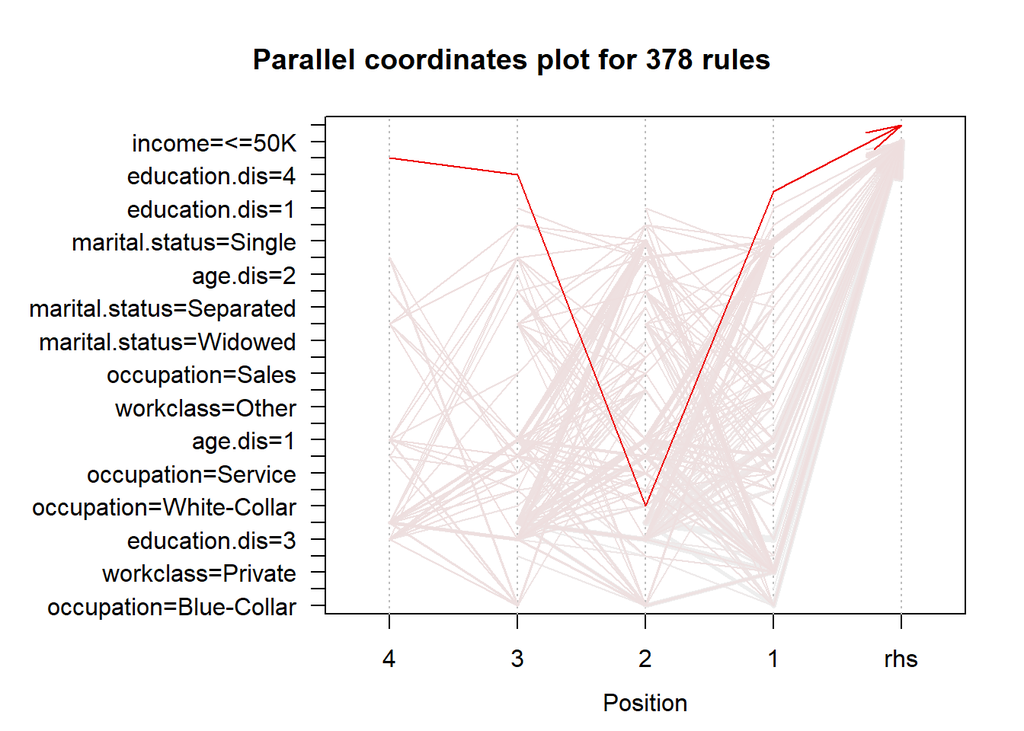

```r
rules_1.sorted = sort(rules(classifier_1), by = "lift")
rules_1.pruned = rules_1.sorted[!is.redundant(rules_1.sorted)]
predd_1 = predict(classifier_1, census_fact_1_ts)
plot(rules_1.pruned,method = "paracoord",measure = "support", shading = "lift", jitter = 0)
```

```r
table(predd_1,census_fact_1_ts$income)
```

```
##
## predd_1 <=50K >50K
##    <     4798 1150
##    >50K   114  450
```

First model shows a decent accuracy rate of 80.58% and missclassification rate of 19.42%.